# Final Project (Predictive Modelling) - Manoj Kumar

## Business Case:

Portuguese Bank wants to predict whether the client will subscribe to their Bank Term Deposit (“Yes” or “No”)

## Data Set Information:

The data used for Predictive Modelling is related with direct marketing campaigns of a Portuguese banking institution. The marketing campaigns were based on phone calls. Often, more than one contact to the same client was required, in order to access if the product (bank term deposit) would be ('yes') or not ('no') subscribed.

## Objective:

The objective here is to Prepare a classification model on train data, based on the data set given and predict our model on test dataset. Attribute details of the datasets are given below.

#### There are 20 attributes in each case of the dataset. They are:

#### age - Numeric value, Age of a customer

#### job - Categorical. Customer job name

#### marital - categorical. Customer's marital status

#### education - Categorical, Customer's educational details

#### default - Categorical, Credit default

#### housing - Categorical, Do the customer have hoising loan

#### loan - Categorical, Do the customer have personl loan

#### contact - Categorical, contact communication type

#### month - Categorical, last contact month of year

#### day_of_week - Categorical, last contact day of the week

#### duration - Numeric data last contact duration in seconds

#### campaign - numeric, number of contacts performed during this campaign and for this client

#### pdays - number of days that passed by after the client was last contacted from a previous campaign

#### previous - number of contacts performed before this campaign and for this client

#### poutcome - categorical, outcome of the previous marketing campaign

#### emp.var.rate - Numeric employment variation rate

#### cons.price.idx - Numeric,consumer price index - monthly indicator

#### cons.conf.idx - Numeric,consumer confidence index - monthly indicator

#### euribor3m - Numeric,euribor 3 month rate - daily indicator

#### nr.employed: number of employees - quarterly indicator

#### -----------------------------------------------------------------------------------------------------------------------------------------

#### Output variable (desired target):

#### has the client subscribed a term deposit? (binary: "yes","no")

# Exploratory Data Analysis

(EDA) is an approach/philosophy for data analysis that employs a variety of techniques (mostly graphical) to maximize insight into a data set; uncover underlying structure; extract important variables; detect outliers and anomalies; test underlying assumptions; develop parsimonious models; and determine optimal factor settings.

Focus: The EDA approach is precisely that--an approach--not a set of techniques, but an attitude/philosophy about how a data analysis should be carried out.

Techniques: Most EDA techniques are graphical in nature with a few quantitative techniques. The reason for the heavy reliance on graphics is that by its very nature the main role of EDA is to open-mindedly explore, and graphics gives the analysts unparalleled power to do so, enticing the data to reveal its structural secrets, and being always ready to gain some new, often unsuspected, insight into the data. In combination with the natural pattern-recognition capabilities that we all possess, graphics provides, of course, unparalleled power to carry this out.

## Importing libraries

```python
import numpy as np
import pandas as pd
import seaborn as sns
import matplotlib.pyplot as plt
# if using a Jupyter notebook, include:
%matplotlib inline
```

```python
# For downloading static plotly graphs
# import sys
# !conda install --yes --prefix {sys.prefix} -c plotly plotly-orca

import numpy as np
import pandas as pd
import seaborn as sns
import matplotlib.pyplot as plt
from matplotlib import rcParams
rcParams.update({'font.size': 15})
plt.rcParams['axes.grid'] = False
from scipy.stats import norm
import plotly.express as px
from plotly.offline import iplot, init_notebook_mode
import plotly.graph_objects as go
from plotly.subplots import make_subplots
import plotly.figure_factory as ff
from bs4 import BeautifulSoup
import requests
import folium
from folium import plugins
import datetime
from sklearn.preprocessing import OrdinalEncoder

# Predictions
#from fbprophet import Prophet
#from fbprophet.plot import plot_plotly, add_changepoints_to_plot
from sklearn.model_selection import train_test_split
from xgboost import XGBRegressor
from xgboost import plot_importance
from sklearn.svm import SVR
from sklearn.linear_model import ElasticNetCV
from sklearn.linear_model import LassoCV
from sklearn.linear_model import Lasso
from sklearn.linear_model import Ridge
from sklearn.metrics import mean_absolute_error
from sklearn.model_selection import cross_val_score
from sklearn.pipeline import make_pipeline
from sklearn.preprocessing import RobustScaler
from statsmodels.tsa.arima_model import ARIMA
from sklearn.linear_model import LinearRegression
import warnings
warnings.filterwarnings('ignore')
sns.set_style('whitegrid')
```

### Reading the dataset

```python
data1 = pd.read_csv("C:/Users/Manoj/Desktop/Final Project/train.csv")
data2 = pd.read_csv("C:/Users/Manoj/Desktop/Final Project/test.csv")
```

### Displaying the dataset

```python
data1
```

|  | age | job | marital | education | default | housing | loan | contact | month | day_of_week | ... | campaign | pdays | previous | poutcome | emp.var.rate | cons.price.idx | cons.conf.idx | euribor3m | nr.employed | y |
| --- | --- | --- | --- | --- | --- | --- | --- | --- | --- | --- | --- | --- | --- | --- | --- | --- | --- | --- | --- | --- | --- |
| 0 | 55 | admin. | married | university.degree | no | no | yes | telephone | jul | fri | ... | 2 | 999 | 0 | nonexistent | 1.4 | 93.918 | -42.7 | 4.963 | 5228.1 | no |
| 1 | 33 | services | married | high.school | no | yes | yes | telephone | may | tue | ... | 1 | 999 | 0 | nonexistent | 1.1 | 93.994 | -36.4 | 4.857 | 5191.0 | no |
| 2 | 40 | housemaid | married | high.school | unknown | yes | no | telephone | jun | mon | ... | 7 | 999 | 0 | nonexistent | 1.4 | 94.465 | -41.8 | 4.961 | 5228.1 | no |
| 3 | 51 | services | married | high.school | unknown | yes | no | telephone | may | wed | ... | 3 | 999 | 0 | nonexistent | 1.1 | 93.994 | -36.4 | 4.859 | 5191.0 | no |
| 4 | 57 | blue-collar | married | basic.9y | no | no | no | telephone | may | fri | ... | 3 | 999 | 0 | nonexistent | 1.1 | 93.994 | -36.4 | 4.864 | 5191.0 | no |
| ... | ... | ... | ... | ... | ... | ... | ... | ... | ... | ... | ... | ... | ... | ... | ... | ... | ... | ... | ... | ... | ... |
| 32945 | 36 | blue-collar | single | basic.6y | unknown | no | no | cellular | jul | mon | ... | 2 | 999 | 0 | nonexistent | 1.4 | 93.918 | -42.7 | 4.960 | 5228.1 | no |
| 32946 | 27 | admin. | single | high.school | unknown | yes | no | cellular | may | tue | ... | 3 | 999 | 0 | nonexistent | -1.8 | 92.893 | -46.2 | 1.291 | 5099.1 | no |
| 32947 | 27 | technician | single | basic.9y | no | no | no | cellular | apr | wed | ... | 3 | 999 | 0 | nonexistent | -1.8 | 93.075 | -47.1 | 1.445 | 5099.1 | no |
| 32948 | 42 | unemployed | married | basic.6y | unknown | no | no | telephone | jun | thu | ... | 2 | 999 | 0 | nonexistent | 1.4 | 94.465 | -41.8 | 4.866 | 5228.1 | no |
| 32949 | 44 | blue-collar | married | unknown | no | yes | no | cellular | aug | wed | ... | 2 | 999 | 0 | nonexistent | 1.4 | 93.444 | -36.1 | 4.967 | 5228.1 | no |

32950 rows × 21 columns

```python
data1 = data1.rename(columns={'emp.var.rate': 'emp_var_rate', 'cons.price.idx': 'cons_price_idx', 'cons.conf.idx': 'cons_conf_idx', 'nr.employed': 'nr_employed'})
data1
```

|  | age | job | marital | education | default | housing | loan | contact | month | day_of_week | ... | campaign | pdays | previous | poutcome | emp_var_rate | cons_price_idx | cons_conf_idx | euribor3m | nr_employed | y |
| --- | --- | --- | --- | --- | --- | --- | --- | --- | --- | --- | --- | --- | --- | --- | --- | --- | --- | --- | --- | --- | --- |
| 0 | 55 | admin. | married | university.degree | no | no | yes | telephone | jul | fri | ... | 2 | 999 | 0 | nonexistent | 1.4 | 93.918 | -42.7 | 4.963 | 5228.1 | no |
| 1 | 33 | services | married | high.school | no | yes | yes | telephone | may | tue | ... | 1 | 999 | 0 | nonexistent | 1.1 | 93.994 | -36.4 | 4.857 | 5191.0 | no |
| 2 | 40 | housemaid | married | high.school | unknown | yes | no | telephone | jun | mon | ... | 7 | 999 | 0 | nonexistent | 1.4 | 94.465 | -41.8 | 4.961 | 5228.1 | no |
| 3 | 51 | services | married | high.school | unknown | yes | no | telephone | may | wed | ... | 3 | 999 | 0 | nonexistent | 1.1 | 93.994 | -36.4 | 4.859 | 5191.0 | no |
| 4 | 57 | blue-collar | married | basic.9y | no | no | no | telephone | may | fri | ... | 3 | 999 | 0 | nonexistent | 1.1 | 93.994 | -36.4 | 4.864 | 5191.0 | no |
| ... | ... | ... | ... | ... | ... | ... | ... | ... | ... | ... | ... | ... | ... | ... | ... | ... | ... | ... | ... | ... | ... |
| 32945 | 36 | blue-collar | single | basic.6y | unknown | no | no | cellular | jul | mon | ... | 2 | 999 | 0 | nonexistent | 1.4 | 93.918 | -42.7 | 4.960 | 5228.1 | no |
| 32946 | 27 | admin. | single | high.school | unknown | yes | no | cellular | may | tue | ... | 3 | 999 | 0 | nonexistent | -1.8 | 92.893 | -46.2 | 1.291 | 5099.1 | no |
| 32947 | 27 | technician | single | basic.9y | no | no | no | cellular | apr | wed | ... | 3 | 999 | 0 | nonexistent | -1.8 | 93.075 | -47.1 | 1.445 | 5099.1 | no |
| 32948 | 42 | unemployed | married | basic.6y | unknown | no | no | telephone | jun | thu | ... | 2 | 999 | 0 | nonexistent | 1.4 | 94.465 | -41.8 | 4.866 | 5228.1 | no |
| 32949 | 44 | blue-collar | married | unknown | no | yes | no | cellular | aug | wed | ... | 2 | 999 | 0 | nonexistent | 1.4 | 93.444 | -36.1 | 4.967 | 5228.1 | no |

32950 rows × 21 columns

### The info() function is used to print a concise summary of a DataFrame. This method prints information about a DataFrame including the index dtype and column dtypes, non-null values and memory usage.

```python
data1.info()
```

```
<class 'pandas.core.frame.DataFrame'>
RangeIndex: 32950 entries, 0 to 32949
Data columns (total 21 columns):
 #   Column          Non-Null Count  Dtype
---  ------          --------------  -----
 0   age             32950 non-null  int64
 1   job             32950 non-null  object
 2   marital         32950 non-null  object
 3   education       32950 non-null  object
 4   default         32950 non-null  object
 5   housing         32950 non-null  object
 6   loan            32950 non-null  object
 7   contact         32950 non-null  object
 8   month           32950 non-null  object
 9   day_of_week     32950 non-null  object
 10  duration        32950 non-null  int64
 11  campaign        32950 non-null  int64
 12  pdays           32950 non-null  int64
 13  previous        32950 non-null  int64
 14  poutcome        32950 non-null  object
 15  emp_var_rate    32950 non-null  float64
 16  cons_price_idx  32950 non-null  float64
 17  cons_conf_idx   32950 non-null  float64
 18  euribor3m       32950 non-null  float64
 19  nr_employed     32950 non-null  float64
 20  y               32950 non-null  object
dtypes: float64(5), int64(5), object(11)
memory usage: 5.3+ MB
```

### Central Limit Theorem: Displays the infomation such as mean, standard deviation, minimum, maximum value, quartiles, etc.

```python
data1.describe()
```

|  | age | duration | campaign | pdays | previous | emp_var_rate | cons_price_idx | cons_conf_idx | euribor3m | nr_employed |
| --- | --- | --- | --- | --- | --- | --- | --- | --- | --- | --- |
| count | 32950.000000 | 32950.000000 | 32950.000000 | 32950.000000 | 32950.000000 | 32950.000000 | 32950.000000 | 32950.000000 | 32950.000000 | 32950.000000 |
| mean | 39.988983 | 258.911229 | 2.562519 | 962.082671 | 0.172170 | 0.084173 | 93.577816 | -40.498804 | 3.623487 | 5167.067706 |
| std | 10.412951 | 260.995384 | 2.764913 | 187.876728 | 0.494968 | 1.571291 | 0.579188 | 4.626062 | 1.734454 | 72.333173 |
| min | 17.000000 | 0.000000 | 1.000000 | 0.000000 | 0.000000 | -3.400000 | 92.201000 | -50.800000 | 0.634000 | 4963.600000 |
| 25% | 32.000000 | 102.000000 | 1.000000 | 999.000000 | 0.000000 | -1.800000 | 93.075000 | -42.700000 | 1.344000 | 5099.100000 |
| 50% | 38.000000 | 180.000000 | 2.000000 | 999.000000 | 0.000000 | 1.100000 | 93.798000 | -41.800000 | 4.857000 | 5191.000000 |
| 75% | 47.000000 | 320.000000 | 3.000000 | 999.000000 | 0.000000 | 1.400000 | 93.994000 | -36.400000 | 4.961000 | 5228.100000 |
| max | 98.000000 | 4918.000000 | 56.000000 | 999.000000 | 7.000000 | 1.400000 | 94.767000 | -26.900000 | 5.045000 | 5228.100000 |

### Displays the datatypes for each variables

```python
data1.dtypes
```

```
age                 int64
job                object
marital            object
education          object
default            object
housing            object
loan               object
contact            object
month              object
day_of_week        object
duration            int64
campaign            int64
pdays               int64
previous            int64
poutcome           object
emp_var_rate      float64
cons_price_idx    float64
cons_conf_idx     float64
euribor3m         float64
nr_employed       float64
y                  object
dtype: object
```

### Displays size of the dataset

```python
data1.shape
```

```
(32950, 21)
```

### Displays first five records from the dataset

```python
data1.head()
```

|  | age | job | marital | education | default | housing | loan | contact | month | day_of_week | ... | campaign | pdays | previous | poutcome | emp_var_rate | cons_price_idx | cons_conf_idx | euribor3m | nr_employed | y |
| --- | --- | --- | --- | --- | --- | --- | --- | --- | --- | --- | --- | --- | --- | --- | --- | --- | --- | --- | --- | --- | --- |
| 0 | 55 | admin. | married | university.degree | no | no | yes | telephone | jul | fri | ... | 2 | 999 | 0 | nonexistent | 1.4 | 93.918 | -42.7 | 4.963 | 5228.1 | no |
| 1 | 33 | services | married | high.school | no | yes | yes | telephone | may | tue | ... | 1 | 999 | 0 | nonexistent | 1.1 | 93.994 | -36.4 | 4.857 | 5191.0 | no |
| 2 | 40 | housemaid | married | high.school | unknown | yes | no | telephone | jun | mon | ... | 7 | 999 | 0 | nonexistent | 1.4 | 94.465 | -41.8 | 4.961 | 5228.1 | no |
| 3 | 51 | services | married | high.school | unknown | yes | no | telephone | may | wed | ... | 3 | 999 | 0 | nonexistent | 1.1 | 93.994 | -36.4 | 4.859 | 5191.0 | no |
| 4 | 57 | blue-collar | married | basic.9y | no | no | no | telephone | may | fri | ... | 3 | 999 | 0 | nonexistent | 1.1 | 93.994 | -36.4 | 4.864 | 5191.0 | no |

5 rows × 21 columns

### Displays last five records from the dataset

```python
data1.tail()
```

|  | age | job | marital | education | default | housing | loan | contact | month | day_of_week | ... | campaign | pdays | previous | poutcome | emp_var_rate | cons_price_idx | cons_conf_idx | euribor3m | nr_employed | y |
| --- | --- | --- | --- | --- | --- | --- | --- | --- | --- | --- | --- | --- | --- | --- | --- | --- | --- | --- | --- | --- | --- |
| 32945 | 36 | blue-collar | single | basic.6y | unknown | no | no | cellular | jul | mon | ... | 2 | 999 | 0 | nonexistent | 1.4 | 93.918 | -42.7 | 4.960 | 5228.1 | no |
| 32946 | 27 | admin. | single | high.school | unknown | yes | no | cellular | may | tue | ... | 3 | 999 | 0 | nonexistent | -1.8 | 92.893 | -46.2 | 1.291 | 5099.1 | no |
| 32947 | 27 | technician | single | basic.9y | no | no | no | cellular | apr | wed | ... | 3 | 999 | 0 | nonexistent | -1.8 | 93.075 | -47.1 | 1.445 | 5099.1 | no |
| 32948 | 42 | unemployed | married | basic.6y | unknown | no | no | telephone | jun | thu | ... | 2 | 999 | 0 | nonexistent | 1.4 | 94.465 | -41.8 | 4.866 | 5228.1 | no |
| 32949 | 44 | blue-collar | married | unknown | no | yes | no | cellular | aug | wed | ... | 2 | 999 | 0 | nonexistent | 1.4 | 93.444 | -36.1 | 4.967 | 5228.1 | no |

5 rows × 21 columns

# Displays the count of unique values from the dataset

```python
data1.nunique()
```

```
age                 77
job                 12
marital              4
education            8
default              3
housing              3
loan                 3
contact              2
month               10
day_of_week          5
duration          1474
campaign            41
pdays               26
previous             8
poutcome             3
emp_var_rate        10
cons_price_idx      26
cons_conf_idx       26
euribor3m          310
nr_employed         11
y                    2
dtype: int64
```

# Finding null values from the dataset

```python
data1.isnull().sum()
```

```
age               0
job               0
marital           0
education         0
default           0
housing           0
loan              0
contact           0
month             0
day_of_week       0
duration          0
campaign          0
pdays             0
previous          0
poutcome          0
emp_var_rate      0
cons_price_idx    0
cons_conf_idx     0
euribor3m         0
nr_employed       0
y                 0
dtype: int64
```

```python
(data1.isnull().sum()*100/len(data1))
```

```
age               0.0
job               0.0
marital           0.0
education         0.0
default           0.0
housing           0.0
loan              0.0
contact           0.0
month             0.0
day_of_week       0.0
duration          0.0
campaign          0.0
pdays             0.0
previous          0.0
poutcome          0.0
emp_var_rate      0.0
cons_price_idx    0.0
cons_conf_idx     0.0
euribor3m         0.0
nr_employed       0.0
y                 0.0
dtype: float64
```

### Displays the complete variables of the dataset

```python
data1.columns
```

```
Index(['age', 'job', 'marital', 'education', 'default', 'housing', 'loan',
       'contact', 'month', 'day_of_week', 'duration', 'campaign', 'pdays',
       'previous', 'poutcome', 'emp_var_rate', 'cons_price_idx',
       'cons_conf_idx', 'euribor3m', 'nr_employed', 'y'],
      dtype='object')
```

```python
print(data1.columns.values)
```

```
['age' 'job' 'marital' 'education' 'default' 'housing' 'loan' 'contact'
 'month' 'day_of_week' 'duration' 'campaign' 'pdays' 'previous' 'poutcome'
 'emp_var_rate' 'cons_price_idx' 'cons_conf_idx' 'euribor3m' 'nr_employed'
 'y']
```

```python
data1.isnull().sum()
```

```
age               0
job               0
marital           0
education         0
default           0
housing           0
loan              0
contact           0
month             0
day_of_week       0
duration          0
campaign          0
pdays             0
previous          0
poutcome          0
emp_var_rate      0
cons_price_idx    0
cons_conf_idx     0
euribor3m         0
nr_employed       0
y                 0
dtype: int64
```

# Univariate Analysis

```python
data1.age.describe()
```

```
count    32950.000000
mean        39.988983
std         10.412951
min         17.000000
25%         32.000000
50%         38.000000
75%         47.000000
max         98.000000
Name: age, dtype: float64
```

```python
age = pd.DataFrame(data1.age.quantile([0.01,0.05,0.1,0.2,0.3,0.4,0.5,0.6,0.7,0.8,0.9,0.95,0.99,1]))
age
```

|  | age |
| --- | --- |
| 0.01 | 23.0 |
| 0.05 | 26.0 |
| 0.10 | 28.0 |
| 0.20 | 31.0 |
| 0.30 | 33.0 |
| 0.40 | 35.0 |
| 0.50 | 38.0 |
| 0.60 | 41.0 |
| 0.70 | 45.0 |
| 0.80 | 49.0 |
| 0.90 | 55.0 |
| 0.95 | 58.0 |
| 0.99 | 71.0 |
| 1.00 | 98.0 |

```python
data1.duration.describe()
```

```
count    32950.000000
mean       258.911229
std        260.995384
min          0.000000
25%        102.000000
50%        180.000000
75%        320.000000
max       4918.000000
Name: duration, dtype: float64
```

```python
duration = pd.DataFrame(data1.duration.quantile([0.01,0.05,0.1,0.2,0.3,0.4,0.5,0.6,0.7,0.8,0.9,0.95,0.99,1]))
duration
```

|  | duration |
| --- | --- |
| 0.01 | 11.00 |
| 0.05 | 36.00 |
| 0.10 | 59.00 |
| 0.20 | 89.00 |
| 0.30 | 116.00 |
| 0.40 | 146.00 |
| 0.50 | 180.00 |
| 0.60 | 222.00 |
| 0.70 | 280.00 |
| 0.80 | 368.00 |
| 0.90 | 552.00 |
| 0.95 | 754.00 |
| 0.99 | 1275.51 |
| 1.00 | 4918.00 |

```python
data1.campaign.describe()
```

```
count    32950.000000
mean         2.562519
std          2.764913
min          1.000000
25%          1.000000
50%          2.000000
75%          3.000000
max         56.000000
Name: campaign, dtype: float64
```

```python
campaign = pd.DataFrame(data1.campaign.quantile([0.01,0.05,0.1,0.2,0.3,0.4,0.5,0.6,0.7,0.8,0.9,0.95,0.99,1]))
campaign
```

|  | campaign |
| --- | --- |
| 0.01 | 1.0 |
| 0.05 | 1.0 |
| 0.10 | 1.0 |
| 0.20 | 1.0 |
| 0.30 | 1.0 |
| 0.40 | 1.0 |
| 0.50 | 2.0 |
| 0.60 | 2.0 |
| 0.70 | 3.0 |
| 0.80 | 3.0 |
| 0.90 | 5.0 |
| 0.95 | 7.0 |
| 0.99 | 14.0 |
| 1.00 | 56.0 |

```python
data1.pdays.describe()
```

```
count    32950.000000
mean       962.082671
std        187.876728
min          0.000000
25%        999.000000
50%        999.000000
75%        999.000000
max        999.000000
Name: pdays, dtype: float64
```

```python
pdays = pd.DataFrame(data1.pdays.quantile([0.01,0.05,0.1,0.2,0.3,0.4,0.5,0.6,0.7,0.8,0.9,0.95,0.99,1]))
pdays
```

|  | pdays |
| --- | --- |
| 0.01 | 3.0 |
| 0.05 | 999.0 |
| 0.10 | 999.0 |
| 0.20 | 999.0 |
| 0.30 | 999.0 |
| 0.40 | 999.0 |
| 0.50 | 999.0 |
| 0.60 | 999.0 |
| 0.70 | 999.0 |
| 0.80 | 999.0 |
| 0.90 | 999.0 |
| 0.95 | 999.0 |
| 0.99 | 999.0 |
| 1.00 | 999.0 |

```python
data1.previous.describe()
```

```
count    32950.000000
mean         0.172170
std          0.494968
min          0.000000
25%          0.000000
50%          0.000000
75%          0.000000
max          7.000000
Name: previous, dtype: float64
```

```python
previous = pd.DataFrame(data1.previous.quantile([0.01,0.05,0.1,0.2,0.3,0.4,0.5,0.6,0.7,0.8,0.9,0.95,0.99,1]))
previous
```

|  | previous |
| --- | --- |
| 0.01 | 0.0 |
| 0.05 | 0.0 |
| 0.10 | 0.0 |
| 0.20 | 0.0 |
| 0.30 | 0.0 |
| 0.40 | 0.0 |
| 0.50 | 0.0 |
| 0.60 | 0.0 |
| 0.70 | 0.0 |
| 0.80 | 0.0 |
| 0.90 | 1.0 |
| 0.95 | 1.0 |
| 0.99 | 2.0 |
| 1.00 | 7.0 |

```python
data1.emp_var_rate.describe()
```

```
count    32950.000000
mean         0.084173
std          1.571291
min         -3.400000
25%         -1.800000
50%          1.100000
75%          1.400000
max          1.400000
Name: emp_var_rate, dtype: float64
```

```python
emp_var_rate = pd.DataFrame(data1.emp_var_rate.quantile([0.01,0.05,0.1,0.2,0.3,0.4,0.5,0.6,0.7,0.8,0.9,0.95,0.99,1]))
emp_var_rate
```

|  | emp_var_rate |
| --- | --- |
| 0.01 | -3.4 |
| 0.05 | -2.9 |
| 0.10 | -1.8 |
| 0.20 | -1.8 |
| 0.30 | -1.7 |
| 0.40 | -0.1 |
| 0.50 | 1.1 |
| 0.60 | 1.1 |
| 0.70 | 1.4 |
| 0.80 | 1.4 |
| 0.90 | 1.4 |
| 0.95 | 1.4 |
| 0.99 | 1.4 |
| 1.00 | 1.4 |

```python
data1.cons_price_idx.describe()
```

```
count    32950.000000
mean        93.577816
std          0.579188
min         92.201000
25%         93.075000
50%         93.798000
75%         93.994000
max         94.767000
Name: cons_price_idx, dtype: float64
```

```python
cons_price_idx = pd.DataFrame(data1.cons_price_idx.quantile([0.01,0.05,0.1,0.2,0.3,0.4,0.5,0.6,0.7,0.8,0.9,0.95,0.99,1]))
cons_price_idx
```

|  | cons_price_idx |
| --- | --- |
| 0.01 | 92.201 |
| 0.05 | 92.713 |
| 0.10 | 92.893 |
| 0.20 | 92.893 |
| 0.30 | 93.200 |
| 0.40 | 93.444 |
| 0.50 | 93.798 |
| 0.60 | 93.918 |
| 0.70 | 93.994 |
| 0.80 | 93.994 |
| 0.90 | 94.465 |
| 0.95 | 94.465 |
| 0.99 | 94.465 |
| 1.00 | 94.767 |

```python
data1.cons_conf_idx.describe()
```

```
count    32950.000000
mean       -40.498804
std          4.626062
min        -50.800000
25%        -42.700000
50%        -41.800000
75%        -36.400000
max        -26.900000
Name: cons_conf_idx, dtype: float64
```

```python
cons_conf_idx = pd.DataFrame(data1.cons_price_idx.quantile([0.01,0.05,0.1,0.2,0.3,0.4,0.5,0.6,0.7,0.8,0.9,0.95,0.99,1]))
cons_conf_idx
```

|  | cons_price_idx |
| --- | --- |
| 0.01 | 92.201 |
| 0.05 | 92.713 |
| 0.10 | 92.893 |
| 0.20 | 92.893 |
| 0.30 | 93.200 |
| 0.40 | 93.444 |
| 0.50 | 93.798 |
| 0.60 | 93.918 |
| 0.70 | 93.994 |
| 0.80 | 93.994 |
| 0.90 | 94.465 |
| 0.95 | 94.465 |
| 0.99 | 94.465 |
| 1.00 | 94.767 |

```python
data1.nr_employed.describe()
```

```
count    32950.000000
mean      5167.067706
std         72.333173
min       4963.600000
25%       5099.100000
50%       5191.000000
75%       5228.100000
max       5228.100000
Name: nr_employed, dtype: float64
```

```python
nr_employed = pd.DataFrame(data1.nr_employed.quantile([0.01,0.05,0.1,0.2,0.3,0.4,0.5,0.6,0.7,0.8,0.9,0.95,0.99,1]))
nr_employed
```

|  | nr_employed |
| --- | --- |
| 0.01 | 4963.6 |
| 0.05 | 5008.7 |
| 0.10 | 5076.2 |
| 0.20 | 5099.1 |
| 0.30 | 5099.1 |
| 0.40 | 5191.0 |
| 0.50 | 5191.0 |
| 0.60 | 5195.8 |
| 0.70 | 5228.1 |
| 0.80 | 5228.1 |
| 0.90 | 5228.1 |
| 0.95 | 5228.1 |
| 0.99 | 5228.1 |
| 1.00 | 5228.1 |

```python
UniVariate = pd.concat([age, duration, campaign, pdays, previous, emp_var_rate, cons_price_idx, cons_conf_idx, nr_employed],axis = 1)
UniVariate
```

|  | age | duration | campaign | pdays | previous | emp_var_rate | cons_price_idx | cons_price_idx | nr_employed |
| --- | --- | --- | --- | --- | --- | --- | --- | --- | --- |
| 0.01 | 23.0 | 11.00 | 1.0 | 3.0 | 0.0 | -3.4 | 92.201 | 92.201 | 4963.6 |
| 0.05 | 26.0 | 36.00 | 1.0 | 999.0 | 0.0 | -2.9 | 92.713 | 92.713 | 5008.7 |
| 0.10 | 28.0 | 59.00 | 1.0 | 999.0 | 0.0 | -1.8 | 92.893 | 92.893 | 5076.2 |
| 0.20 | 31.0 | 89.00 | 1.0 | 999.0 | 0.0 | -1.8 | 92.893 | 92.893 | 5099.1 |
| 0.30 | 33.0 | 116.00 | 1.0 | 999.0 | 0.0 | -1.7 | 93.200 | 93.200 | 5099.1 |
| 0.40 | 35.0 | 146.00 | 1.0 | 999.0 | 0.0 | -0.1 | 93.444 | 93.444 | 5191.0 |
| 0.50 | 38.0 | 180.00 | 2.0 | 999.0 | 0.0 | 1.1 | 93.798 | 93.798 | 5191.0 |
| 0.60 | 41.0 | 222.00 | 2.0 | 999.0 | 0.0 | 1.1 | 93.918 | 93.918 | 5195.8 |
| 0.70 | 45.0 | 280.00 | 3.0 | 999.0 | 0.0 | 1.4 | 93.994 | 93.994 | 5228.1 |
| 0.80 | 49.0 | 368.00 | 3.0 | 999.0 | 0.0 | 1.4 | 93.994 | 93.994 | 5228.1 |
| 0.90 | 55.0 | 552.00 | 5.0 | 999.0 | 1.0 | 1.4 | 94.465 | 94.465 | 5228.1 |
| 0.95 | 58.0 | 754.00 | 7.0 | 999.0 | 1.0 | 1.4 | 94.465 | 94.465 | 5228.1 |
| 0.99 | 71.0 | 1275.51 | 14.0 | 999.0 | 2.0 | 1.4 | 94.465 | 94.465 | 5228.1 |
| 1.00 | 98.0 | 4918.00 | 56.0 | 999.0 | 7.0 | 1.4 | 94.767 | 94.767 | 5228.1 |

```python
data1['Count'] = 1
```

```python
data1.head()
```

|  | age | job | marital | education | default | housing | loan | contact | month | day_of_week | ... | pdays | previous | poutcome | emp_var_rate | cons_price_idx | cons_conf_idx | euribor3m | nr_employed | y | Count |
| --- | --- | --- | --- | --- | --- | --- | --- | --- | --- | --- | --- | --- | --- | --- | --- | --- | --- | --- | --- | --- | --- |
| 0 | 55 | admin. | married | university.degree | no | no | yes | telephone | jul | fri | ... | 999 | 0 | nonexistent | 1.4 | 93.918 | -42.7 | 4.963 | 5228.1 | no | 1 |
| 1 | 33 | services | married | high.school | no | yes | yes | telephone | may | tue | ... | 999 | 0 | nonexistent | 1.1 | 93.994 | -36.4 | 4.857 | 5191.0 | no | 1 |
| 2 | 40 | housemaid | married | high.school | unknown | yes | no | telephone | jun | mon | ... | 999 | 0 | nonexistent | 1.4 | 94.465 | -41.8 | 4.961 | 5228.1 | no | 1 |
| 3 | 51 | services | married | high.school | unknown | yes | no | telephone | may | wed | ... | 999 | 0 | nonexistent | 1.1 | 93.994 | -36.4 | 4.859 | 5191.0 | no | 1 |
| 4 | 57 | blue-collar | married | basic.9y | no | no | no | telephone | may | fri | ... | 999 | 0 | nonexistent | 1.1 | 93.994 | -36.4 | 4.864 | 5191.0 | no | 1 |

5 rows × 22 columns

```python
job_table = data1.pivot_table(values=["Count"],index=["job"],aggfunc = len)
print (job_table)
```

```
               Count
job
admin.          8340
blue-collar     7418
entrepreneur    1159
housemaid        835
management      2359
retired         1379
self-employed   1150
services        3168
student          707
technician      5383
unemployed       789
unknown          263
```

```python
def prop(x):
    return x/sum(x)

prop_prop = job_table.apply(prop)
job_table['Freq%'] = prop_prop['Count']
job_table
```

| job | Count | Freq% |
| --- | --- | --- |
| admin. | 8340 | 0.253111 |
| blue-collar | 7418 | 0.225129 |
| entrepreneur | 1159 | 0.035175 |
| housemaid | 835 | 0.025341 |
| management | 2359 | 0.071593 |
| retired | 1379 | 0.041851 |
| self-employed | 1150 | 0.034901 |
| services | 3168 | 0.096146 |
| student | 707 | 0.021457 |
| technician | 5383 | 0.163369 |
| unemployed | 789 | 0.023945 |
| unknown | 263 | 0.007982 |

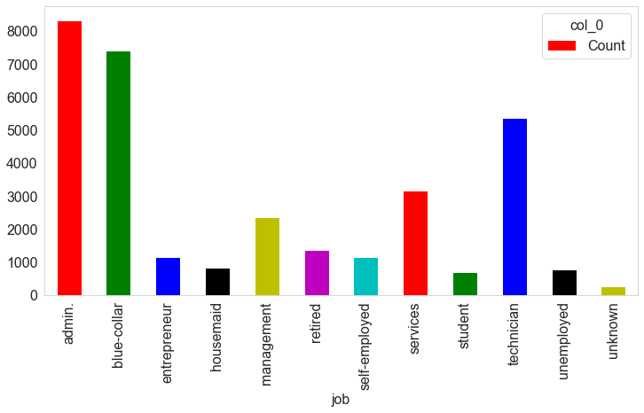

```python
rcParams.update({'font.size': 16})
plt.rcParams['axes.grid'] = False
my_tab = pd.crosstab(index = data1["job"], columns="Count")
my_tab.plot.bar(color='rgbkymc', figsize=(12,6), width = 0.5)
```

```python
my_tab
```

| col_0 job | Count |
| --- | --- |
| admin. | 8340 |
| blue-collar | 7418 |
| entrepreneur | 1159 |
| housemaid | 835 |
| management | 2359 |
| retired | 1379 |
| self-employed | 1150 |
| services | 3168 |
| student | 707 |
| technician | 5383 |
| unemployed | 789 |
| unknown | 263 |

```python
marital_table = data1.pivot_table(values=["Count"],index=["marital"],aggfunc = len)
print (marital_table)
```

```
          Count
marital
divorced   3656
married   19946
single     9282
unknown      66
```

```python
def prop(x):
    return x/sum(x)

prop_prop = marital_table.apply(prop)
marital_table['Freq%'] = prop_prop['Count']
marital_table
```

| marital | Count | Freq% |
| --- | --- | --- |
| divorced | 3656 | 0.110956 |
| married | 19946 | 0.605341 |
| single | 9282 | 0.281700 |
| unknown | 66 | 0.002003 |

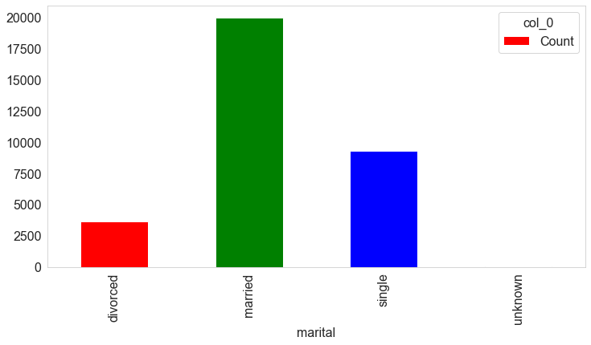

```python
rcParams.update({'font.size': 16})
plt.rcParams['axes.grid'] = False
my_tab = pd.crosstab(index = data1["marital"], columns="Count")
my_tab.plot.bar(color='rgbkymc', figsize=(12,6), width = 0.5)
```

```python
education_table = data1.pivot_table(values=["Count"],index=["education"],aggfunc = len)
print (education_table)
```

```
                     Count
education
basic.4y              3370
basic.6y              1822
basic.9y              4829
high.school           7668
illiterate              10
professional.course   4185
university.degree     9696
unknown               1370
```

```python
def prop(x):
    return x/sum(x)

prop_prop = education_table.apply(prop)
education_table['Freq%'] = prop_prop['Count']
education_table
```

| education | Count | Freq% |
| --- | --- | --- |
| basic.4y | 3370 | 0.102276 |
| basic.6y | 1822 | 0.055296 |
| basic.9y | 4829 | 0.146555 |
| high.school | 7668 | 0.232716 |
| illiterate | 10 | 0.000303 |
| professional.course | 4185 | 0.127011 |
| university.degree | 9696 | 0.294264 |
| unknown | 1370 | 0.041578 |

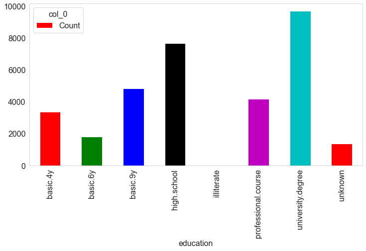

```python
rcParams.update({'font.size': 16})
plt.rcParams['axes.grid'] = False
my_tab = pd.crosstab(index = data1["education"], columns="Count")
my_tab.plot.bar(color='rgbkymc', figsize=(12,6), width = 0.5)
```

```python
default_table = data1.pivot_table(values=["Count"],index=["default"],aggfunc = len)
print (default_table)
```

```
         Count
default
no       26055
unknown   6892
yes          3
```

```python
def prop(x):
    return x/sum(x)

prop_prop = default_table.apply(prop)
default_table['Freq%'] = prop_prop['Count']
default_table
```

| default | Count | Freq% |
| --- | --- | --- |
| no | 26055 | 0.790744 |
| unknown | 6892 | 0.209165 |
| yes | 3 | 0.000091 |

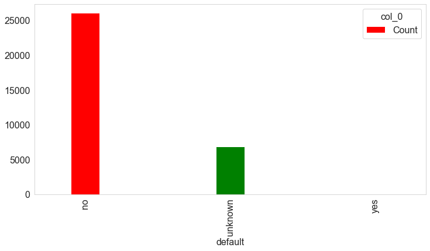

```python
rcParams.update({'font.size': 16})
plt.rcParams['axes.grid'] = False
my_tab = pd.crosstab(index = data1["default"], columns="Count")
my_tab.plot.bar(color='rgbkymc', figsize=(12,6), width = 0.2)
```

```python
housing_table = data1.pivot_table(values=["Count"],index=["housing"],aggfunc = len)
print (housing_table)
```

```
         Count
housing
no       14895
unknown    784
yes      17271
```

```python
def prop(x):
    return x/sum(x)

prop_prop = housing_table.apply(prop)
housing_table['Freq%'] = prop_prop['Count']
housing_table
```

| housing | Count | Freq% |
| --- | --- | --- |
| no | 14895 | 0.452049 |
| unknown | 784 | 0.023794 |
| yes | 17271 | 0.524158 |

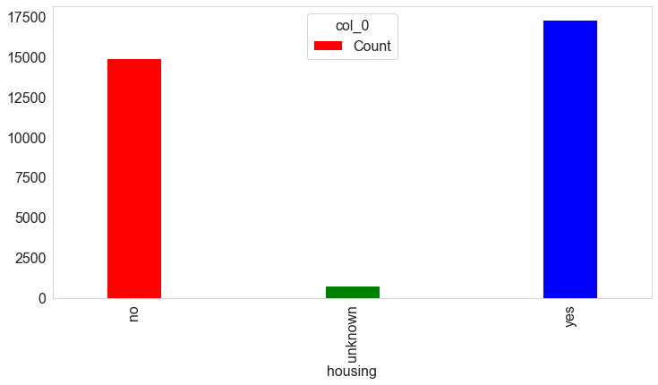

```python
rcParams.update({'font.size': 16})
plt.rcParams['axes.grid'] = False
my_tab = pd.crosstab(index = data1["housing"], columns="Count")
my_tab.plot.bar(color='rgbkymc', figsize=(12,6), width = 0.25)
```

```python
loan_table = data1.pivot_table(values=["Count"],index=["loan"],aggfunc = len)
print (loan_table)
```

```
         Count
loan
no       27134
unknown    784
yes       5032
```

```python
def prop(x):
    return x/sum(x)

prop_prop = loan_table.apply(prop)
loan_table['Freq%'] = prop_prop['Count']
loan_table
```

| loan | Count | Freq% |
| --- | --- | --- |
| no | 27134 | 0.823490 |
| unknown | 784 | 0.023794 |
| yes | 5032 | 0.152716 |

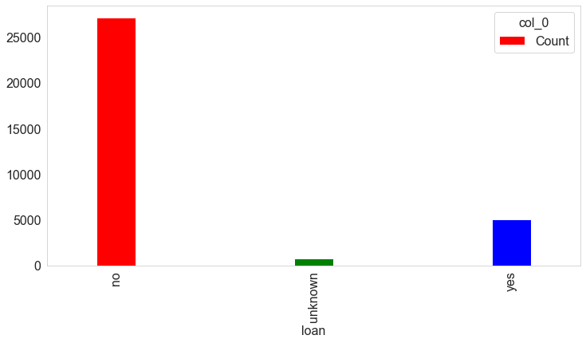

```python
rcParams.update({'font.size': 16})
plt.rcParams['axes.grid'] = False
my_tab = pd.crosstab(index = data1["loan"], columns="Count")
my_tab.plot.bar(color='rgbkymc', figsize=(12,6), width = 0.2)
```

```python
contact_table = data1.pivot_table(values=["Count"],index=["contact"],aggfunc = len)
print (contact_table)
```

```
           Count
contact
cellular   20897
telephone  12053
```

```python
def prop(x):
    return x/sum(x)

prop_prop = contact_table.apply(prop)
contact_table['Freq%'] = prop_prop['Count']
contact_table
```

| contact | Count | Freq% |
| --- | --- | --- |
| cellular | 20897 | 0.634203 |
| telephone | 12053 | 0.365797 |

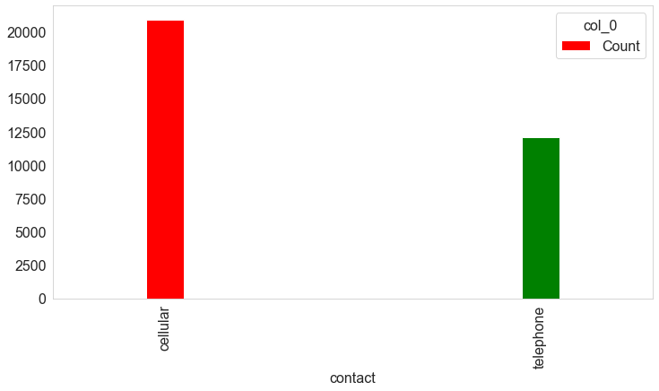

```python
rcParams.update({'font.size': 16})
plt.rcParams['axes.grid'] = False
my_tab = pd.crosstab(index = data1["contact"], columns="Count")
my_tab.plot.bar(color='rgbkymc', figsize=(12,6), width = 0.1)
```

```python
month_table = data1.pivot_table(values=["Count"],index=["month"],aggfunc = len)
print (month_table)
```

```
       Count
month
apr     2091
aug     4912
dec      136
jul     5766
jun     4287
mar      441
may    11008
nov     3253
oct      582
sep      474
```

```python
def prop(x):
    return x/sum(x)

prop_prop = month_table.apply(prop)
month_table['Freq%'] = prop_prop['Count']
month_table
```

| month | Count | Freq% |
| --- | --- | --- |
| apr | 2091 | 0.063460 |
| aug | 4912 | 0.149074 |
| dec | 136 | 0.004127 |
| jul | 5766 | 0.174992 |
| jun | 4287 | 0.130106 |
| mar | 441 | 0.013384 |
| may | 11008 | 0.334082 |
| nov | 3253 | 0.098725 |
| oct | 582 | 0.017663 |
| sep | 474 | 0.014385 |

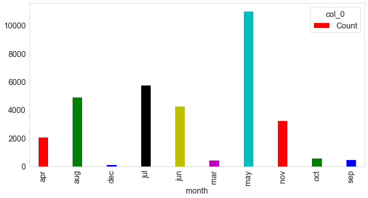

```python
rcParams.update({'font.size': 16})
plt.rcParams['axes.grid'] = False
my_tab = pd.crosstab(index = data1["month"], columns="Count")
my_tab.plot.bar(color='rgbkymc', figsize=(12,6), width = 0.3)
```

```python
day_of_week_table = data1.pivot_table(values=["Count"],index=["day_of_week"],aggfunc = len)
print (day_of_week_table)
```

```
             Count
day_of_week
fri           6310
mon           6795
thu           6919
tue           6428
wed           6498
```

```python
def prop(x):
    return x/sum(x)

prop_prop = day_of_week_table.apply(prop)
day_of_week_table['Freq%'] = prop_prop['Count']
day_of_week_table
```

| day_of_week | Count | Freq% |
| --- | --- | --- |
| fri | 6310 | 0.191502 |
| mon | 6795 | 0.206222 |
| thu | 6919 | 0.209985 |
| tue | 6428 | 0.195083 |
| wed | 6498 | 0.197208 |

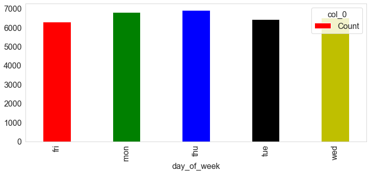

```python
rcParams.update({'font.size': 16})
plt.rcParams['axes.grid'] = False
my_tab = pd.crosstab(index = data1["day_of_week"], columns="Count")
my_tab.plot.bar(color='rgbkymc', figsize=(12,5), width = 0.4)
```

```python
poutcome_table = data1.pivot_table(values=["Count"],index=["poutcome"],aggfunc = len)
print (poutcome_table)
```

```
             Count
poutcome
failure       3360
nonexistent  28476
success       1114
```

```python
def prop(x):
    return x/sum(x)

prop_prop = poutcome_table.apply(prop)
poutcome_table['Freq%'] = prop_prop['Count']
poutcome_table
```

| poutcome | Count | Freq% |
| --- | --- | --- |
| failure | 3360 | 0.101973 |
| nonexistent | 28476 | 0.864219 |
| success | 1114 | 0.033809 |

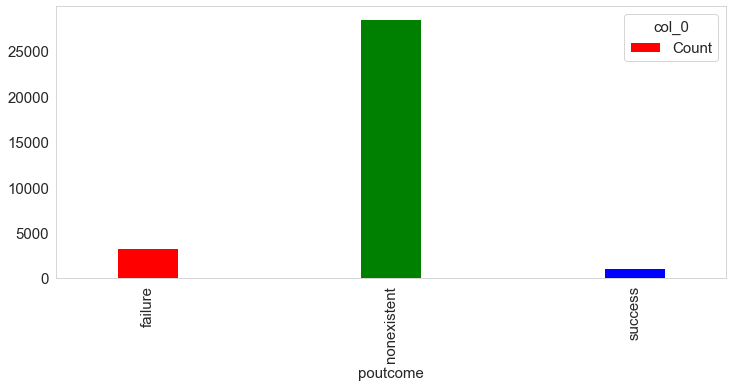

```python
rcParams.update({'font.size': 15})
plt.rcParams['axes.grid'] = False
my_tab = pd.crosstab(index = data1["poutcome"], columns="Count")
my_tab.plot.bar(color='rgbkymc', figsize=(12,5), width = 0.25)
```

```
count    32950.000000
mean        39.988983
std         10.412951
min         17.000000
25%         32.000000
50%         38.000000
75%         47.000000
max         98.000000
Name: age, dtype: float64
```

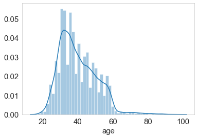

```python
sns.distplot(data1['age']);
data1.age.describe()
```

```python
age = pd.DataFrame(data1.age.quantile([0,0.01,0.05,0.1,0.2,0.3,0.4,0.5,0.6,0.7,0.8,0.9,0.95,0.99,1]))
age
```

|  | age |
| --- | --- |
| 0.00 | 17.0 |
| 0.01 | 23.0 |
| 0.05 | 26.0 |
| 0.10 | 28.0 |
| 0.20 | 31.0 |
| 0.30 | 33.0 |
| 0.40 | 35.0 |
| 0.50 | 38.0 |
| 0.60 | 41.0 |
| 0.70 | 45.0 |
| 0.80 | 49.0 |
| 0.90 | 55.0 |
| 0.95 | 58.0 |
| 0.99 | 71.0 |
| 1.00 | 98.0 |

```python
data1['age']=np.where(data1['age'] <1, 1, data1['age'])
```

```
count    32950.000000
mean        39.988983
std         10.412951
min         17.000000
25%         32.000000
50%         38.000000
75%         47.000000
max         98.000000
Name: age, dtype: float64
```

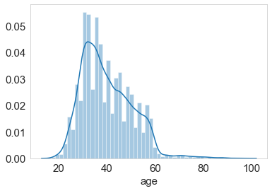

```python
sns.distplot(data1['age']);
data1.age.describe()
```

```python
age = pd.DataFrame(data1.age.quantile([0,0.01,0.05,0.1,0.2,0.3,0.4,0.5,0.6,0.7,0.8,0.9,0.95,0.99,1]))
age
```

|  | age |
| --- | --- |
| 0.00 | 17.0 |
| 0.01 | 23.0 |
| 0.05 | 26.0 |
| 0.10 | 28.0 |
| 0.20 | 31.0 |
| 0.30 | 33.0 |
| 0.40 | 35.0 |
| 0.50 | 38.0 |
| 0.60 | 41.0 |
| 0.70 | 45.0 |
| 0.80 | 49.0 |
| 0.90 | 55.0 |
| 0.95 | 58.0 |
| 0.99 | 71.0 |
| 1.00 | 98.0 |

```
count    32950.000000
mean       258.911229
std        260.995384
min          0.000000
25%        102.000000
50%        180.000000
75%        320.000000
max       4918.000000
Name: duration, dtype: float64
```

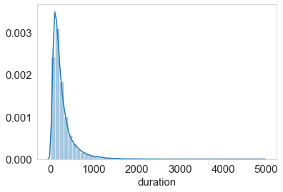

```python
#duration
sns.distplot(data1['duration']);
data1.duration.describe()
```

```python
duration = pd.DataFrame(data1.duration.quantile([0,0.01,0.05,0.1,0.2,0.3,0.4,0.5,0.6,0.7,0.8,0.9,0.95,0.99,1]))
duration
```

|  | duration |
| --- | --- |
| 0.00 | 0.00 |
| 0.01 | 11.00 |
| 0.05 | 36.00 |
| 0.10 | 59.00 |
| 0.20 | 89.00 |
| 0.30 | 116.00 |
| 0.40 | 146.00 |
| 0.50 | 180.00 |
| 0.60 | 222.00 |
| 0.70 | 280.00 |
| 0.80 | 368.00 |
| 0.90 | 552.00 |
| 0.95 | 754.00 |
| 0.99 | 1275.51 |
| 1.00 | 4918.00 |

```python
lower_bound = 0.02
upper_bound = 0.99
res_inc = data1['duration'].quantile([lower_bound, upper_bound])
res_inc
```

```
0.02      17.00
0.99    1275.51
Name: duration, dtype: float64
```

```
count    32950.000000
mean       237.695599
std        183.278305
min          1.000000
25%        102.000000
50%        180.000000
75%        320.000000
max        680.000000
Name: duration, dtype: float64
```

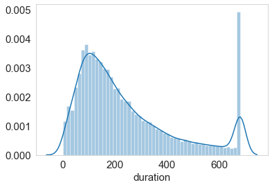

```python
data1['duration']=np.where(data1['duration'] >680, 680, data1['duration'])
data1['duration']=np.where(data1['duration'] <1, 1, data1['duration'])
sns.distplot(data1['duration'])
data1.duration.describe()
```

### Removing 'unknown' or 'nan' from Job column (if any) Also, converting nan in Job to empty strings to later convert them to null values for data imputation

```python
def preprocess01(job):
    job = job.astype(str).str.replace("unknown", "")
    job = job.str.replace("nan", "")
    return job
data1['job'] = preprocess01(data1['job'])
data1
```

|  | age | job | marital | education | default | housing | loan | contact | month | day_of_week | ... | pdays | previous | poutcome | emp_var_rate | cons_price_idx | cons_conf_idx | euribor3m | nr_employed | y | Count |
| --- | --- | --- | --- | --- | --- | --- | --- | --- | --- | --- | --- | --- | --- | --- | --- | --- | --- | --- | --- | --- | --- |
| 0 | 55 | admin. | married | university.degree | no | no | yes | telephone | jul | fri | ... | 999 | 0 | nonexistent | 1.4 | 93.918 | -42.7 | 4.963 | 5228.1 | no | 1 |
| 1 | 33 | services | married | high.school | no | yes | yes | telephone | may | tue | ... | 999 | 0 | nonexistent | 1.1 | 93.994 | -36.4 | 4.857 | 5191.0 | no | 1 |
| 2 | 40 | housemaid | married | high.school | unknown | yes | no | telephone | jun | mon | ... | 999 | 0 | nonexistent | 1.4 | 94.465 | -41.8 | 4.961 | 5228.1 | no | 1 |
| 3 | 51 | services | married | high.school | unknown | yes | no | telephone | may | wed | ... | 999 | 0 | nonexistent | 1.1 | 93.994 | -36.4 | 4.859 | 5191.0 | no | 1 |
| 4 | 57 | blue-collar | married | basic.9y | no | no | no | telephone | may | fri | ... | 999 | 0 | nonexistent | 1.1 | 93.994 | -36.4 | 4.864 | 5191.0 | no | 1 |
| ... | ... | ... | ... | ... | ... | ... | ... | ... | ... | ... | ... | ... | ... | ... | ... | ... | ... | ... | ... | ... | ... |
| 32945 | 36 | blue-collar | single | basic.6y | unknown | no | no | cellular | jul | mon | ... | 999 | 0 | nonexistent | 1.4 | 93.918 | -42.7 | 4.960 | 5228.1 | no | 1 |
| 32946 | 27 | admin. | single | high.school | unknown | yes | no | cellular | may | tue | ... | 999 | 0 | nonexistent | -1.8 | 92.893 | -46.2 | 1.291 | 5099.1 | no | 1 |
| 32947 | 27 | technician | single | basic.9y | no | no | no | cellular | apr | wed | ... | 999 | 0 | nonexistent | -1.8 | 93.075 | -47.1 | 1.445 | 5099.1 | no | 1 |
| 32948 | 42 | unemployed | married | basic.6y | unknown | no | no | telephone | jun | thu | ... | 999 | 0 | nonexistent | 1.4 | 94.465 | -41.8 | 4.866 | 5228.1 | no | 1 |
| 32949 | 44 | blue-collar | married | unknown | no | yes | no | cellular | aug | wed | ... | 999 | 0 | nonexistent | 1.4 | 93.444 | -36.1 | 4.967 | 5228.1 | no | 1 |

32950 rows × 22 columns

### Converting Empty Strings to Null. As the missing values might be in form empty strings which Pandas doesn't recognise

```python
data1['job'].replace('', np.nan, inplace=True)
data1
```

|  | age | job | marital | education | default | housing | loan | contact | month | day_of_week | ... | pdays | previous | poutcome | emp_var_rate | cons_price_idx | cons_conf_idx | euribor3m | nr_employed | y | Count |
| --- | --- | --- | --- | --- | --- | --- | --- | --- | --- | --- | --- | --- | --- | --- | --- | --- | --- | --- | --- | --- | --- |
| 0 | 55 | admin. | married | university.degree | no | no | yes | telephone | jul | fri | ... | 999 | 0 | nonexistent | 1.4 | 93.918 | -42.7 | 4.963 | 5228.1 | no | 1 |
| 1 | 33 | services | married | high.school | no | yes | yes | telephone | may | tue | ... | 999 | 0 | nonexistent | 1.1 | 93.994 | -36.4 | 4.857 | 5191.0 | no | 1 |
| 2 | 40 | housemaid | married | high.school | unknown | yes | no | telephone | jun | mon | ... | 999 | 0 | nonexistent | 1.4 | 94.465 | -41.8 | 4.961 | 5228.1 | no | 1 |
| 3 | 51 | services | married | high.school | unknown | yes | no | telephone | may | wed | ... | 999 | 0 | nonexistent | 1.1 | 93.994 | -36.4 | 4.859 | 5191.0 | no | 1 |
| 4 | 57 | blue-collar | married | basic.9y | no | no | no | telephone | may | fri | ... | 999 | 0 | nonexistent | 1.1 | 93.994 | -36.4 | 4.864 | 5191.0 | no | 1 |
| ... | ... | ... | ... | ... | ... | ... | ... | ... | ... | ... | ... | ... | ... | ... | ... | ... | ... | ... | ... | ... | ... |
| 32945 | 36 | blue-collar | single | basic.6y | unknown | no | no | cellular | jul | mon | ... | 999 | 0 | nonexistent | 1.4 | 93.918 | -42.7 | 4.960 | 5228.1 | no | 1 |
| 32946 | 27 | admin. | single | high.school | unknown | yes | no | cellular | may | tue | ... | 999 | 0 | nonexistent | -1.8 | 92.893 | -46.2 | 1.291 | 5099.1 | no | 1 |
| 32947 | 27 | technician | single | basic.9y | no | no | no | cellular | apr | wed | ... | 999 | 0 | nonexistent | -1.8 | 93.075 | -47.1 | 1.445 | 5099.1 | no | 1 |
| 32948 | 42 | unemployed | married | basic.6y | unknown | no | no | telephone | jun | thu | ... | 999 | 0 | nonexistent | 1.4 | 94.465 | -41.8 | 4.866 | 5228.1 | no | 1 |
| 32949 | 44 | blue-collar | married | unknown | no | yes | no | cellular | aug | wed | ... | 999 | 0 | nonexistent | 1.4 | 93.444 | -36.1 | 4.967 | 5228.1 | no | 1 |

32950 rows × 22 columns

```python
def preprocess02(marital):
    marital = marital.astype(str).str.replace("unknown", "")
    marital = marital.str.replace("nan", "")
    return marital
data1['marital'] = preprocess02(data1['marital'])
data1
```

|  | age | job | marital | education | default | housing | loan | contact | month | day_of_week | ... | pdays | previous | poutcome | emp_var_rate | cons_price_idx | cons_conf_idx | euribor3m | nr_employed | y | Count |
| --- | --- | --- | --- | --- | --- | --- | --- | --- | --- | --- | --- | --- | --- | --- | --- | --- | --- | --- | --- | --- | --- |
| 0 | 55 | admin. | married | university.degree | no | no | yes | telephone | jul | fri | ... | 999 | 0 | nonexistent | 1.4 | 93.918 | -42.7 | 4.963 | 5228.1 | no | 1 |
| 1 | 33 | services | married | high.school | no | yes | yes | telephone | may | tue | ... | 999 | 0 | nonexistent | 1.1 | 93.994 | -36.4 | 4.857 | 5191.0 | no | 1 |
| 2 | 40 | housemaid | married | high.school | unknown | yes | no | telephone | jun | mon | ... | 999 | 0 | nonexistent | 1.4 | 94.465 | -41.8 | 4.961 | 5228.1 | no | 1 |
| 3 | 51 | services | married | high.school | unknown | yes | no | telephone | may | wed | ... | 999 | 0 | nonexistent | 1.1 | 93.994 | -36.4 | 4.859 | 5191.0 | no | 1 |
| 4 | 57 | blue-collar | married | basic.9y | no | no | no | telephone | may | fri | ... | 999 | 0 | nonexistent | 1.1 | 93.994 | -36.4 | 4.864 | 5191.0 | no | 1 |
| ... | ... | ... | ... | ... | ... | ... | ... | ... | ... | ... | ... | ... | ... | ... | ... | ... | ... | ... | ... | ... | ... |
| 32945 | 36 | blue-collar | single | basic.6y | unknown | no | no | cellular | jul | mon | ... | 999 | 0 | nonexistent | 1.4 | 93.918 | -42.7 | 4.960 | 5228.1 | no | 1 |
| 32946 | 27 | admin. | single | high.school | unknown | yes | no | cellular | may | tue | ... | 999 | 0 | nonexistent | -1.8 | 92.893 | -46.2 | 1.291 | 5099.1 | no | 1 |
| 32947 | 27 | technician | single | basic.9y | no | no | no | cellular | apr | wed | ... | 999 | 0 | nonexistent | -1.8 | 93.075 | -47.1 | 1.445 | 5099.1 | no | 1 |
| 32948 | 42 | unemployed | married | basic.6y | unknown | no | no | telephone | jun | thu | ... | 999 | 0 | nonexistent | 1.4 | 94.465 | -41.8 | 4.866 | 5228.1 | no | 1 |
| 32949 | 44 | blue-collar | married | unknown | no | yes | no | cellular | aug | wed | ... | 999 | 0 | nonexistent | 1.4 | 93.444 | -36.1 | 4.967 | 5228.1 | no | 1 |

32950 rows × 22 columns

```python
data1['marital'].replace('', np.nan, inplace=True)
data1
```

|  | age | job | marital | education | default | housing | loan | contact | month | day_of_week | ... | pdays | previous | poutcome | emp_var_rate | cons_price_idx | cons_conf_idx | euribor3m | nr_employed | y | Count |
| --- | --- | --- | --- | --- | --- | --- | --- | --- | --- | --- | --- | --- | --- | --- | --- | --- | --- | --- | --- | --- | --- |
| 0 | 55 | admin. | married | university.degree | no | no | yes | telephone | jul | fri | ... | 999 | 0 | nonexistent | 1.4 | 93.918 | -42.7 | 4.963 | 5228.1 | no | 1 |
| 1 | 33 | services | married | high.school | no | yes | yes | telephone | may | tue | ... | 999 | 0 | nonexistent | 1.1 | 93.994 | -36.4 | 4.857 | 5191.0 | no | 1 |
| 2 | 40 | housemaid | married | high.school | unknown | yes | no | telephone | jun | mon | ... | 999 | 0 | nonexistent | 1.4 | 94.465 | -41.8 | 4.961 | 5228.1 | no | 1 |
| 3 | 51 | services | married | high.school | unknown | yes | no | telephone | may | wed | ... | 999 | 0 | nonexistent | 1.1 | 93.994 | -36.4 | 4.859 | 5191.0 | no | 1 |
| 4 | 57 | blue-collar | married | basic.9y | no | no | no | telephone | may | fri | ... | 999 | 0 | nonexistent | 1.1 | 93.994 | -36.4 | 4.864 | 5191.0 | no | 1 |
| ... | ... | ... | ... | ... | ... | ... | ... | ... | ... | ... | ... | ... | ... | ... | ... | ... | ... | ... | ... | ... | ... |
| 32945 | 36 | blue-collar | single | basic.6y | unknown | no | no | cellular | jul | mon | ... | 999 | 0 | nonexistent | 1.4 | 93.918 | -42.7 | 4.960 | 5228.1 | no | 1 |
| 32946 | 27 | admin. | single | high.school | unknown | yes | no | cellular | may | tue | ... | 999 | 0 | nonexistent | -1.8 | 92.893 | -46.2 | 1.291 | 5099.1 | no | 1 |
| 32947 | 27 | technician | single | basic.9y | no | no | no | cellular | apr | wed | ... | 999 | 0 | nonexistent | -1.8 | 93.075 | -47.1 | 1.445 | 5099.1 | no | 1 |
| 32948 | 42 | unemployed | married | basic.6y | unknown | no | no | telephone | jun | thu | ... | 999 | 0 | nonexistent | 1.4 | 94.465 | -41.8 | 4.866 | 5228.1 | no | 1 |
| 32949 | 44 | blue-collar | married | unknown | no | yes | no | cellular | aug | wed | ... | 999 | 0 | nonexistent | 1.4 | 93.444 | -36.1 | 4.967 | 5228.1 | no | 1 |

32950 rows × 22 columns

```python
def preprocess03(education):
    education = education.astype(str).str.replace("unknown", "")
    education = education.str.replace("nan", "")
    return education
data1['education'] = preprocess03(data1['education'])
data1
```

|  | age | job | marital | education | default | housing | loan | contact | month | day_of_week | ... | pdays | previous | poutcome | emp_var_rate | cons_price_idx | cons_conf_idx | euribor3m | nr_employed | y | Count |
| --- | --- | --- | --- | --- | --- | --- | --- | --- | --- | --- | --- | --- | --- | --- | --- | --- | --- | --- | --- | --- | --- |
| 0 | 55 | admin. | married | university.degree | no | no | yes | telephone | jul | fri | ... | 999 | 0 | nonexistent | 1.4 | 93.918 | -42.7 | 4.963 | 5228.1 | no | 1 |
| 1 | 33 | services | married | high.school | no | yes | yes | telephone | may | tue | ... | 999 | 0 | nonexistent | 1.1 | 93.994 | -36.4 | 4.857 | 5191.0 | no | 1 |
| 2 | 40 | housemaid | married | high.school | unknown | yes | no | telephone | jun | mon | ... | 999 | 0 | nonexistent | 1.4 | 94.465 | -41.8 | 4.961 | 5228.1 | no | 1 |
| 3 | 51 | services | married | high.school | unknown | yes | no | telephone | may | wed | ... | 999 | 0 | nonexistent | 1.1 | 93.994 | -36.4 | 4.859 | 5191.0 | no | 1 |
| 4 | 57 | blue-collar | married | basic.9y | no | no | no | telephone | may | fri | ... | 999 | 0 | nonexistent | 1.1 | 93.994 | -36.4 | 4.864 | 5191.0 | no | 1 |
| ... | ... | ... | ... | ... | ... | ... | ... | ... | ... | ... | ... | ... | ... | ... | ... | ... | ... | ... | ... | ... | ... |
| 32945 | 36 | blue-collar | single | basic.6y | unknown | no | no | cellular | jul | mon | ... | 999 | 0 | nonexistent | 1.4 | 93.918 | -42.7 | 4.960 | 5228.1 | no | 1 |
| 32946 | 27 | admin. | single | high.school | unknown | yes | no | cellular | may | tue | ... | 999 | 0 | nonexistent | -1.8 | 92.893 | -46.2 | 1.291 | 5099.1 | no | 1 |
| 32947 | 27 | technician | single | basic.9y | no | no | no | cellular | apr | wed | ... | 999 | 0 | nonexistent | -1.8 | 93.075 | -47.1 | 1.445 | 5099.1 | no | 1 |
| 32948 | 42 | unemployed | married | basic.6y | unknown | no | no | telephone | jun | thu | ... | 999 | 0 | nonexistent | 1.4 | 94.465 | -41.8 | 4.866 | 5228.1 | no | 1 |
| 32949 | 44 | blue-collar | married |  | no | yes | no | cellular | aug | wed | ... | 999 | 0 | nonexistent | 1.4 | 93.444 | -36.1 | 4.967 | 5228.1 | no | 1 |

32950 rows × 22 columns

```python
data1['education'].replace('', np.nan, inplace=True)
data1
```

|  | age | job | marital | education | default | housing | loan | contact | month | day_of_week | ... | pdays | previous | poutcome | emp_var_rate | cons_price_idx | cons_conf_idx | euribor3m | nr_employed | y | Count |
| --- | --- | --- | --- | --- | --- | --- | --- | --- | --- | --- | --- | --- | --- | --- | --- | --- | --- | --- | --- | --- | --- |
| 0 | 55 | admin. | married | university.degree | no | no | yes | telephone | jul | fri | ... | 999 | 0 | nonexistent | 1.4 | 93.918 | -42.7 | 4.963 | 5228.1 | no | 1 |
| 1 | 33 | services | married | high.school | no | yes | yes | telephone | may | tue | ... | 999 | 0 | nonexistent | 1.1 | 93.994 | -36.4 | 4.857 | 5191.0 | no | 1 |
| 2 | 40 | housemaid | married | high.school | unknown | yes | no | telephone | jun | mon | ... | 999 | 0 | nonexistent | 1.4 | 94.465 | -41.8 | 4.961 | 5228.1 | no | 1 |
| 3 | 51 | services | married | high.school | unknown | yes | no | telephone | may | wed | ... | 999 | 0 | nonexistent | 1.1 | 93.994 | -36.4 | 4.859 | 5191.0 | no | 1 |
| 4 | 57 | blue-collar | married | basic.9y | no | no | no | telephone | may | fri | ... | 999 | 0 | nonexistent | 1.1 | 93.994 | -36.4 | 4.864 | 5191.0 | no | 1 |
| ... | ... | ... | ... | ... | ... | ... | ... | ... | ... | ... | ... | ... | ... | ... | ... | ... | ... | ... | ... | ... | ... |
| 32945 | 36 | blue-collar | single | basic.6y | unknown | no | no | cellular | jul | mon | ... | 999 | 0 | nonexistent | 1.4 | 93.918 | -42.7 | 4.960 | 5228.1 | no | 1 |
| 32946 | 27 | admin. | single | high.school | unknown | yes | no | cellular | may | tue | ... | 999 | 0 | nonexistent | -1.8 | 92.893 | -46.2 | 1.291 | 5099.1 | no | 1 |
| 32947 | 27 | technician | single | basic.9y | no | no | no | cellular | apr | wed | ... | 999 | 0 | nonexistent | -1.8 | 93.075 | -47.1 | 1.445 | 5099.1 | no | 1 |
| 32948 | 42 | unemployed | married | basic.6y | unknown | no | no | telephone | jun | thu | ... | 999 | 0 | nonexistent | 1.4 | 94.465 | -41.8 | 4.866 | 5228.1 | no | 1 |
| 32949 | 44 | blue-collar | married | NaN | no | yes | no | cellular | aug | wed | ... | 999 | 0 | nonexistent | 1.4 | 93.444 | -36.1 | 4.967 | 5228.1 | no | 1 |

32950 rows × 22 columns

```python
def preprocess04(default):
    default = default.astype(str).str.replace("unknown", "")
    default = default.str.replace("nan", "")
    return default
data1['default'] = preprocess04(data1['default'])
data1
```

|  | age | job | marital | education | default | housing | loan | contact | month | day_of_week | ... | pdays | previous | poutcome | emp_var_rate | cons_price_idx | cons_conf_idx | euribor3m | nr_employed | y | Count |
| --- | --- | --- | --- | --- | --- | --- | --- | --- | --- | --- | --- | --- | --- | --- | --- | --- | --- | --- | --- | --- | --- |
| 0 | 55 | admin. | married | university.degree | no | no | yes | telephone | jul | fri | ... | 999 | 0 | nonexistent | 1.4 | 93.918 | -42.7 | 4.963 | 5228.1 | no | 1 |
| 1 | 33 | services | married | high.school | no | yes | yes | telephone | may | tue | ... | 999 | 0 | nonexistent | 1.1 | 93.994 | -36.4 | 4.857 | 5191.0 | no | 1 |
| 2 | 40 | housemaid | married | high.school |  | yes | no | telephone | jun | mon | ... | 999 | 0 | nonexistent | 1.4 | 94.465 | -41.8 | 4.961 | 5228.1 | no | 1 |
| 3 | 51 | services | married | high.school |  | yes | no | telephone | may | wed | ... | 999 | 0 | nonexistent | 1.1 | 93.994 | -36.4 | 4.859 | 5191.0 | no | 1 |
| 4 | 57 | blue-collar | married | basic.9y | no | no | no | telephone | may | fri | ... | 999 | 0 | nonexistent | 1.1 | 93.994 | -36.4 | 4.864 | 5191.0 | no | 1 |
| ... | ... | ... | ... | ... | ... | ... | ... | ... | ... | ... | ... | ... | ... | ... | ... | ... | ... | ... | ... | ... | ... |
| 32945 | 36 | blue-collar | single | basic.6y |  | no | no | cellular | jul | mon | ... | 999 | 0 | nonexistent | 1.4 | 93.918 | -42.7 | 4.960 | 5228.1 | no | 1 |
| 32946 | 27 | admin. | single | high.school |  | yes | no | cellular | may | tue | ... | 999 | 0 | nonexistent | -1.8 | 92.893 | -46.2 | 1.291 | 5099.1 | no | 1 |
| 32947 | 27 | technician | single | basic.9y | no | no | no | cellular | apr | wed | ... | 999 | 0 | nonexistent | -1.8 | 93.075 | -47.1 | 1.445 | 5099.1 | no | 1 |
| 32948 | 42 | unemployed | married | basic.6y |  | no | no | telephone | jun | thu | ... | 999 | 0 | nonexistent | 1.4 | 94.465 | -41.8 | 4.866 | 5228.1 | no | 1 |
| 32949 | 44 | blue-collar | married | NaN | no | yes | no | cellular | aug | wed | ... | 999 | 0 | nonexistent | 1.4 | 93.444 | -36.1 | 4.967 | 5228.1 | no | 1 |

32950 rows × 22 columns

```python
data1['default'].replace('', np.nan, inplace=True)
data1
```

|  | age | job | marital | education | default | housing | loan | contact | month | day_of_week | ... | pdays | previous | poutcome | emp_var_rate | cons_price_idx | cons_conf_idx | euribor3m | nr_employed | y | Count |
| --- | --- | --- | --- | --- | --- | --- | --- | --- | --- | --- | --- | --- | --- | --- | --- | --- | --- | --- | --- | --- | --- |
| 0 | 55 | admin. | married | university.degree | no | no | yes | telephone | jul | fri | ... | 999 | 0 | nonexistent | 1.4 | 93.918 | -42.7 | 4.963 | 5228.1 | no | 1 |
| 1 | 33 | services | married | high.school | no | yes | yes | telephone | may | tue | ... | 999 | 0 | nonexistent | 1.1 | 93.994 | -36.4 | 4.857 | 5191.0 | no | 1 |
| 2 | 40 | housemaid | married | high.school | NaN | yes | no | telephone | jun | mon | ... | 999 | 0 | nonexistent | 1.4 | 94.465 | -41.8 | 4.961 | 5228.1 | no | 1 |
| 3 | 51 | services | married | high.school | NaN | yes | no | telephone | may | wed | ... | 999 | 0 | nonexistent | 1.1 | 93.994 | -36.4 | 4.859 | 5191.0 | no | 1 |
| 4 | 57 | blue-collar | married | basic.9y | no | no | no | telephone | may | fri | ... | 999 | 0 | nonexistent | 1.1 | 93.994 | -36.4 | 4.864 | 5191.0 | no | 1 |
| ... | ... | ... | ... | ... | ... | ... | ... | ... | ... | ... | ... | ... | ... | ... | ... | ... | ... | ... | ... | ... | ... |
| 32945 | 36 | blue-collar | single | basic.6y | NaN | no | no | cellular | jul | mon | ... | 999 | 0 | nonexistent | 1.4 | 93.918 | -42.7 | 4.960 | 5228.1 | no | 1 |
| 32946 | 27 | admin. | single | high.school | NaN | yes | no | cellular | may | tue | ... | 999 | 0 | nonexistent | -1.8 | 92.893 | -46.2 | 1.291 | 5099.1 | no | 1 |
| 32947 | 27 | technician | single | basic.9y | no | no | no | cellular | apr | wed | ... | 999 | 0 | nonexistent | -1.8 | 93.075 | -47.1 | 1.445 | 5099.1 | no | 1 |
| 32948 | 42 | unemployed | married | basic.6y | NaN | no | no | telephone | jun | thu | ... | 999 | 0 | nonexistent | 1.4 | 94.465 | -41.8 | 4.866 | 5228.1 | no | 1 |
| 32949 | 44 | blue-collar | married | NaN | no | yes | no | cellular | aug | wed | ... | 999 | 0 | nonexistent | 1.4 | 93.444 | -36.1 | 4.967 | 5228.1 | no | 1 |

32950 rows × 22 columns

```python
def preprocess05(housing):
    housing = housing.astype(str).str.replace("unknown", "")
    housing = housing.str.replace("nan", "")
    return housing
data1['housing'] = preprocess05(data1['housing'])
data1
```

|  | age | job | marital | education | default | housing | loan | contact | month | day_of_week | ... | pdays | previous | poutcome | emp_var_rate | cons_price_idx | cons_conf_idx | euribor3m | nr_employed | y | Count |
| --- | --- | --- | --- | --- | --- | --- | --- | --- | --- | --- | --- | --- | --- | --- | --- | --- | --- | --- | --- | --- | --- |
| 0 | 55 | admin. | married | university.degree | no | no | yes | telephone | jul | fri | ... | 999 | 0 | nonexistent | 1.4 | 93.918 | -42.7 | 4.963 | 5228.1 | no | 1 |
| 1 | 33 | services | married | high.school | no | yes | yes | telephone | may | tue | ... | 999 | 0 | nonexistent | 1.1 | 93.994 | -36.4 | 4.857 | 5191.0 | no | 1 |
| 2 | 40 | housemaid | married | high.school | NaN | yes | no | telephone | jun | mon | ... | 999 | 0 | nonexistent | 1.4 | 94.465 | -41.8 | 4.961 | 5228.1 | no | 1 |
| 3 | 51 | services | married | high.school | NaN | yes | no | telephone | may | wed | ... | 999 | 0 | nonexistent | 1.1 | 93.994 | -36.4 | 4.859 | 5191.0 | no | 1 |
| 4 | 57 | blue-collar | married | basic.9y | no | no | no | telephone | may | fri | ... | 999 | 0 | nonexistent | 1.1 | 93.994 | -36.4 | 4.864 | 5191.0 | no | 1 |
| ... | ... | ... | ... | ... | ... | ... | ... | ... | ... | ... | ... | ... | ... | ... | ... | ... | ... | ... | ... | ... | ... |
| 32945 | 36 | blue-collar | single | basic.6y | NaN | no | no | cellular | jul | mon | ... | 999 | 0 | nonexistent | 1.4 | 93.918 | -42.7 | 4.960 | 5228.1 | no | 1 |
| 32946 | 27 | admin. | single | high.school | NaN | yes | no | cellular | may | tue | ... | 999 | 0 | nonexistent | -1.8 | 92.893 | -46.2 | 1.291 | 5099.1 | no | 1 |
| 32947 | 27 | technician | single | basic.9y | no | no | no | cellular | apr | wed | ... | 999 | 0 | nonexistent | -1.8 | 93.075 | -47.1 | 1.445 | 5099.1 | no | 1 |
| 32948 | 42 | unemployed | married | basic.6y | NaN | no | no | telephone | jun | thu | ... | 999 | 0 | nonexistent | 1.4 | 94.465 | -41.8 | 4.866 | 5228.1 | no | 1 |
| 32949 | 44 | blue-collar | married | NaN | no | yes | no | cellular | aug | wed | ... | 999 | 0 | nonexistent | 1.4 | 93.444 | -36.1 | 4.967 | 5228.1 | no | 1 |

32950 rows × 22 columns

```python
data1['housing'].replace('', np.nan, inplace=True)
data1
```

|  | age | job | marital | education | default | housing | loan | contact | month | day_of_week | ... | pdays | previous | poutcome | emp_var_rate | cons_price_idx | cons_conf_idx | euribor3m | nr_employed | y | Count |
| --- | --- | --- | --- | --- | --- | --- | --- | --- | --- | --- | --- | --- | --- | --- | --- | --- | --- | --- | --- | --- | --- |
| 0 | 55 | admin. | married | university.degree | no | no | yes | telephone | jul | fri | ... | 999 | 0 | nonexistent | 1.4 | 93.918 | -42.7 | 4.963 | 5228.1 | no | 1 |
| 1 | 33 | services | married | high.school | no | yes | yes | telephone | may | tue | ... | 999 | 0 | nonexistent | 1.1 | 93.994 | -36.4 | 4.857 | 5191.0 | no | 1 |
| 2 | 40 | housemaid | married | high.school | NaN | yes | no | telephone | jun | mon | ... | 999 | 0 | nonexistent | 1.4 | 94.465 | -41.8 | 4.961 | 5228.1 | no | 1 |
| 3 | 51 | services | married | high.school | NaN | yes | no | telephone | may | wed | ... | 999 | 0 | nonexistent | 1.1 | 93.994 | -36.4 | 4.859 | 5191.0 | no | 1 |
| 4 | 57 | blue-collar | married | basic.9y | no | no | no | telephone | may | fri | ... | 999 | 0 | nonexistent | 1.1 | 93.994 | -36.4 | 4.864 | 5191.0 | no | 1 |
| ... | ... | ... | ... | ... | ... | ... | ... | ... | ... | ... | ... | ... | ... | ... | ... | ... | ... | ... | ... | ... | ... |
| 32945 | 36 | blue-collar | single | basic.6y | NaN | no | no | cellular | jul | mon | ... | 999 | 0 | nonexistent | 1.4 | 93.918 | -42.7 | 4.960 | 5228.1 | no | 1 |
| 32946 | 27 | admin. | single | high.school | NaN | yes | no | cellular | may | tue | ... | 999 | 0 | nonexistent | -1.8 | 92.893 | -46.2 | 1.291 | 5099.1 | no | 1 |
| 32947 | 27 | technician | single | basic.9y | no | no | no | cellular | apr | wed | ... | 999 | 0 | nonexistent | -1.8 | 93.075 | -47.1 | 1.445 | 5099.1 | no | 1 |
| 32948 | 42 | unemployed | married | basic.6y | NaN | no | no | telephone | jun | thu | ... | 999 | 0 | nonexistent | 1.4 | 94.465 | -41.8 | 4.866 | 5228.1 | no | 1 |
| 32949 | 44 | blue-collar | married | NaN | no | yes | no | cellular | aug | wed | ... | 999 | 0 | nonexistent | 1.4 | 93.444 | -36.1 | 4.967 | 5228.1 | no | 1 |

32950 rows × 22 columns

```python
def preprocess06(loan):
    loan = loan.astype(str).str.replace("unknown", "")
    loan = loan.str.replace("nan", "")
    return loan
data1['loan'] = preprocess06(data1['loan'])
data1
```

|  | age | job | marital | education | default | housing | loan | contact | month | day_of_week | ... | pdays | previous | poutcome | emp_var_rate | cons_price_idx | cons_conf_idx | euribor3m | nr_employed | y | Count |
| --- | --- | --- | --- | --- | --- | --- | --- | --- | --- | --- | --- | --- | --- | --- | --- | --- | --- | --- | --- | --- | --- |
| 0 | 55 | admin. | married | university.degree | no | no | yes | telephone | jul | fri | ... | 999 | 0 | nonexistent | 1.4 | 93.918 | -42.7 | 4.963 | 5228.1 | no | 1 |
| 1 | 33 | services | married | high.school | no | yes | yes | telephone | may | tue | ... | 999 | 0 | nonexistent | 1.1 | 93.994 | -36.4 | 4.857 | 5191.0 | no | 1 |
| 2 | 40 | housemaid | married | high.school | NaN | yes | no | telephone | jun | mon | ... | 999 | 0 | nonexistent | 1.4 | 94.465 | -41.8 | 4.961 | 5228.1 | no | 1 |
| 3 | 51 | services | married | high.school | NaN | yes | no | telephone | may | wed | ... | 999 | 0 | nonexistent | 1.1 | 93.994 | -36.4 | 4.859 | 5191.0 | no | 1 |
| 4 | 57 | blue-collar | married | basic.9y | no | no | no | telephone | may | fri | ... | 999 | 0 | nonexistent | 1.1 | 93.994 | -36.4 | 4.864 | 5191.0 | no | 1 |
| ... | ... | ... | ... | ... | ... | ... | ... | ... | ... | ... | ... | ... | ... | ... | ... | ... | ... | ... | ... | ... | ... |
| 32945 | 36 | blue-collar | single | basic.6y | NaN | no | no | cellular | jul | mon | ... | 999 | 0 | nonexistent | 1.4 | 93.918 | -42.7 | 4.960 | 5228.1 | no | 1 |
| 32946 | 27 | admin. | single | high.school | NaN | yes | no | cellular | may | tue | ... | 999 | 0 | nonexistent | -1.8 | 92.893 | -46.2 | 1.291 | 5099.1 | no | 1 |
| 32947 | 27 | technician | single | basic.9y | no | no | no | cellular | apr | wed | ... | 999 | 0 | nonexistent | -1.8 | 93.075 | -47.1 | 1.445 | 5099.1 | no | 1 |
| 32948 | 42 | unemployed | married | basic.6y | NaN | no | no | telephone | jun | thu | ... | 999 | 0 | nonexistent | 1.4 | 94.465 | -41.8 | 4.866 | 5228.1 | no | 1 |
| 32949 | 44 | blue-collar | married | NaN | no | yes | no | cellular | aug | wed | ... | 999 | 0 | nonexistent | 1.4 | 93.444 | -36.1 | 4.967 | 5228.1 | no | 1 |

32950 rows × 22 columns

```python
data1['loan'].replace('', np.nan, inplace=True)
data1
```

|  | age | job | marital | education | default | housing | loan | contact | month | day_of_week | ... | pdays | previous | poutcome | emp_var_rate | cons_price_idx | cons_conf_idx | euribor3m | nr_employed | y | Count |
| --- | --- | --- | --- | --- | --- | --- | --- | --- | --- | --- | --- | --- | --- | --- | --- | --- | --- | --- | --- | --- | --- |
| 0 | 55 | admin. | married | university.degree | no | no | yes | telephone | jul | fri | ... | 999 | 0 | nonexistent | 1.4 | 93.918 | -42.7 | 4.963 | 5228.1 | no | 1 |
| 1 | 33 | services | married | high.school | no | yes | yes | telephone | may | tue | ... | 999 | 0 | nonexistent | 1.1 | 93.994 | -36.4 | 4.857 | 5191.0 | no | 1 |
| 2 | 40 | housemaid | married | high.school | NaN | yes | no | telephone | jun | mon | ... | 999 | 0 | nonexistent | 1.4 | 94.465 | -41.8 | 4.961 | 5228.1 | no | 1 |
| 3 | 51 | services | married | high.school | NaN | yes | no | telephone | may | wed | ... | 999 | 0 | nonexistent | 1.1 | 93.994 | -36.4 | 4.859 | 5191.0 | no | 1 |
| 4 | 57 | blue-collar | married | basic.9y | no | no | no | telephone | may | fri | ... | 999 | 0 | nonexistent | 1.1 | 93.994 | -36.4 | 4.864 | 5191.0 | no | 1 |
| ... | ... | ... | ... | ... | ... | ... | ... | ... | ... | ... | ... | ... | ... | ... | ... | ... | ... | ... | ... | ... | ... |
| 32945 | 36 | blue-collar | single | basic.6y | NaN | no | no | cellular | jul | mon | ... | 999 | 0 | nonexistent | 1.4 | 93.918 | -42.7 | 4.960 | 5228.1 | no | 1 |
| 32946 | 27 | admin. | single | high.school | NaN | yes | no | cellular | may | tue | ... | 999 | 0 | nonexistent | -1.8 | 92.893 | -46.2 | 1.291 | 5099.1 | no | 1 |
| 32947 | 27 | technician | single | basic.9y | no | no | no | cellular | apr | wed | ... | 999 | 0 | nonexistent | -1.8 | 93.075 | -47.1 | 1.445 | 5099.1 | no | 1 |
| 32948 | 42 | unemployed | married | basic.6y | NaN | no | no | telephone | jun | thu | ... | 999 | 0 | nonexistent | 1.4 | 94.465 | -41.8 | 4.866 | 5228.1 | no | 1 |
| 32949 | 44 | blue-collar | married | NaN | no | yes | no | cellular | aug | wed | ... | 999 | 0 | nonexistent | 1.4 | 93.444 | -36.1 | 4.967 | 5228.1 | no | 1 |

32950 rows × 22 columns

# Displays the different types of values for each variables from the dataset

```python
data1.nunique()
```

```
age                77
job                11
marital             3
education           7
default             2
housing             2
loan                2
contact             2
month              10
day_of_week         5
duration          680
campaign           41
pdays              26
previous            8
poutcome            3
emp_var_rate       10
cons_price_idx     26
cons_conf_idx      26
euribor3m         310
nr_employed        11
y                   2
Count               1
dtype: int64
```

# Finding null values from the dataset

```python
data1.isnull().sum()
```

```
age                  0
job                263
marital             66
education         1370
default           6892
housing            784
loan               784
contact              0
month                0
day_of_week          0
duration             0
campaign             0
pdays                0
previous             0
poutcome             0
emp_var_rate         0
cons_price_idx       0
cons_conf_idx        0
euribor3m            0
nr_employed          0
y                    0
Count                0
dtype: int64
```

```python
(data1.isnull().sum()*100/len(data1))
```

```
age                0.000000
job                0.798179
marital            0.200303
education          4.157815
default           20.916540
housing            2.379363
loan               2.379363
contact            0.000000
month              0.000000
day_of_week        0.000000
duration           0.000000
campaign           0.000000
pdays              0.000000
previous           0.000000
poutcome           0.000000
emp_var_rate       0.000000
cons_price_idx     0.000000
cons_conf_idx      0.000000
euribor3m          0.000000
nr_employed        0.000000
y                  0.000000
Count              0.000000
dtype: float64
```

```python
data1.columns
```

```
Index(['age', 'job', 'marital', 'education', 'default', 'housing', 'loan',
       'contact', 'month', 'day_of_week', 'duration', 'campaign', 'pdays',
       'previous', 'poutcome', 'emp_var_rate', 'cons_price_idx',
       'cons_conf_idx', 'euribor3m', 'nr_employed', 'y', 'Count'],
      dtype='object')
```

# Bi-Variate Analysis

### Categorical variables relation with Target

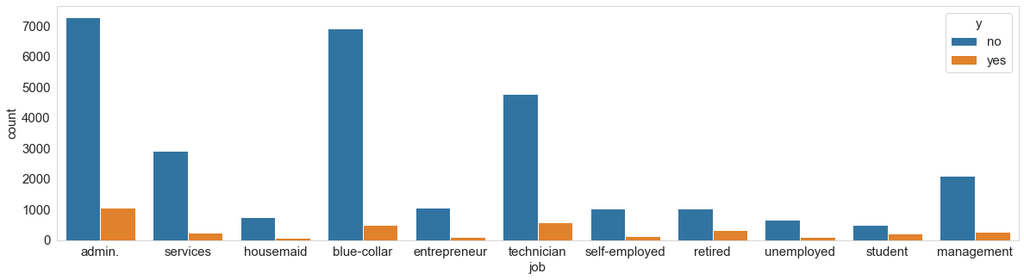

```python
plt.figure(figsize=(20,5))
sns.countplot(x="job", data=data1, hue="y")
```

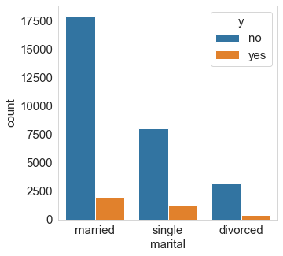

```python
plt.figure(figsize=(5,5))
sns.countplot(x="marital", data=data1, hue="y")
```

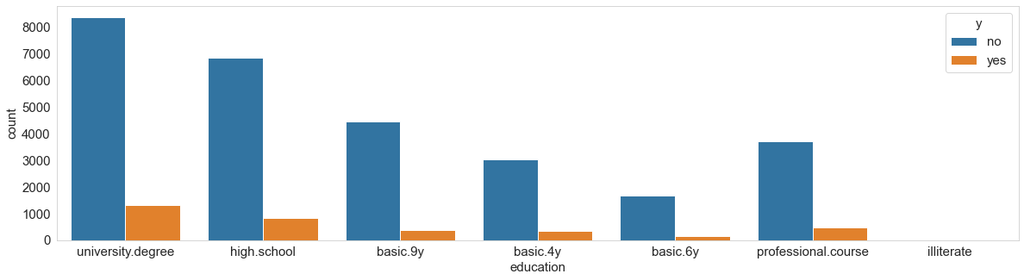

```python
plt.figure(figsize=(20,5))
sns.countplot(x="education", data=data1, hue="y")
```

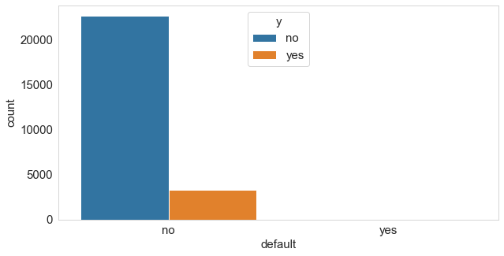

```python
plt.figure(figsize=(10,5))
sns.countplot(x="default", data=data1, hue="y")
```

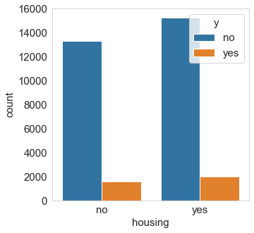

```python
plt.figure(figsize=(5,5))
sns.countplot(x="housing", data=data1, hue="y")
```

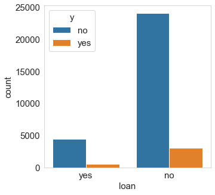

```python
plt.figure(figsize=(5,5))
sns.countplot(x="loan", data=data1, hue="y")
```

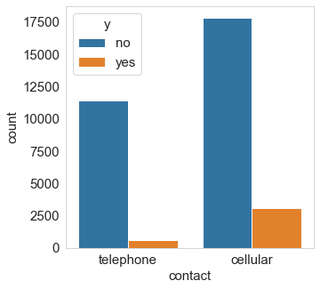

```python
plt.figure(figsize=(5,5))
sns.countplot(x="contact", data=data1, hue="y")
```

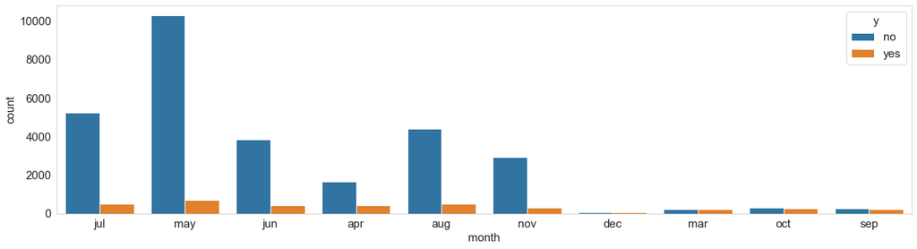

```python
plt.figure(figsize=(20,5))
sns.countplot(x="month", data=data1, hue="y")
```

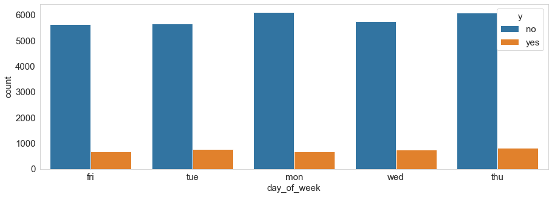

```python
plt.figure(figsize=(15,5))
sns.countplot(x="day_of_week", data=data1, hue="y")
```

### Heat Map showing correlation

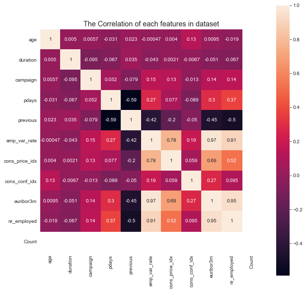

```python
# Calculating the correlation of each variables
correlation = data1.corr()
### Ploting the correlation
%matplotlib inline
plt.figure(figsize =(10,10))
sns.heatmap(data= correlation, annot =True, square= True)
plt.title('The Correlation of each features in dataset', fontsize= 'x-large')
plt.show()
```

```python
data1
```

|  | age | job | marital | education | default | housing | loan | contact | month | day_of_week | ... | pdays | previous | poutcome | emp_var_rate | cons_price_idx | cons_conf_idx | euribor3m | nr_employed | y | Count |
| --- | --- | --- | --- | --- | --- | --- | --- | --- | --- | --- | --- | --- | --- | --- | --- | --- | --- | --- | --- | --- | --- |
| 0 | 55 | admin. | married | university.degree | no | no | yes | telephone | jul | fri | ... | 999 | 0 | nonexistent | 1.4 | 93.918 | -42.7 | 4.963 | 5228.1 | no | 1 |
| 1 | 33 | services | married | high.school | no | yes | yes | telephone | may | tue | ... | 999 | 0 | nonexistent | 1.1 | 93.994 | -36.4 | 4.857 | 5191.0 | no | 1 |
| 2 | 40 | housemaid | married | high.school | NaN | yes | no | telephone | jun | mon | ... | 999 | 0 | nonexistent | 1.4 | 94.465 | -41.8 | 4.961 | 5228.1 | no | 1 |
| 3 | 51 | services | married | high.school | NaN | yes | no | telephone | may | wed | ... | 999 | 0 | nonexistent | 1.1 | 93.994 | -36.4 | 4.859 | 5191.0 | no | 1 |
| 4 | 57 | blue-collar | married | basic.9y | no | no | no | telephone | may | fri | ... | 999 | 0 | nonexistent | 1.1 | 93.994 | -36.4 | 4.864 | 5191.0 | no | 1 |
| ... | ... | ... | ... | ... | ... | ... | ... | ... | ... | ... | ... | ... | ... | ... | ... | ... | ... | ... | ... | ... | ... |
| 32945 | 36 | blue-collar | single | basic.6y | NaN | no | no | cellular | jul | mon | ... | 999 | 0 | nonexistent | 1.4 | 93.918 | -42.7 | 4.960 | 5228.1 | no | 1 |
| 32946 | 27 | admin. | single | high.school | NaN | yes | no | cellular | may | tue | ... | 999 | 0 | nonexistent | -1.8 | 92.893 | -46.2 | 1.291 | 5099.1 | no | 1 |
| 32947 | 27 | technician | single | basic.9y | no | no | no | cellular | apr | wed | ... | 999 | 0 | nonexistent | -1.8 | 93.075 | -47.1 | 1.445 | 5099.1 | no | 1 |
| 32948 | 42 | unemployed | married | basic.6y | NaN | no | no | telephone | jun | thu | ... | 999 | 0 | nonexistent | 1.4 | 94.465 | -41.8 | 4.866 | 5228.1 | no | 1 |
| 32949 | 44 | blue-collar | married | NaN | no | yes | no | cellular | aug | wed | ... | 999 | 0 | nonexistent | 1.4 | 93.444 | -36.1 | 4.967 | 5228.1 | no | 1 |

32950 rows × 22 columns

```python
data1.isnull().sum()
```

```
age                  0
job                263
marital             66
education         1370
default           6892
housing            784
loan               784
contact              0
month                0
day_of_week          0
duration             0
campaign             0
pdays                0
previous             0
poutcome             0
emp_var_rate         0
cons_price_idx       0
cons_conf_idx        0
euribor3m            0
nr_employed          0
y                    0
Count                0
dtype: int64
```

```python
# Function to calculate missing values by column
def missing_values_table(data1):

    # Total missing values
    mis_val = data1.isnull().sum()

    # Percentage of missing values
    mis_val_percent = 100 * data1.isnull().sum() / len(data1)

    # Make a table with the results
    mis_val_table = pd.concat([mis_val, mis_val_percent], axis=1)

    # Rename the columns
    mis_val_table_ren_columns = mis_val_table.rename(
    columns = {0 : 'Missing Values', 1 : '% of Total Values'})

    # Sort the table by percentage of missing descending
    # .iloc[:, 1]!= 0: filter on missing missing values not equal to zero
    mis_val_table_ren_columns = mis_val_table_ren_columns[
        mis_val_table_ren_columns.iloc[:,1] != 0].sort_values(
    '% of Total Values', ascending=False).round(2)  # round(2), keep 2 digits

    # Print some summary information
    print("Your slelected dataframe has {} columns.".format(data1.shape[1]) + '\n' +
    "There are {} columns that have missing values.".format(mis_val_table_ren_columns.shape[0]))

    # Return the dataframe with missing information
    return mis_val_table_ren_columns
```

```python
from sklearn.impute import SimpleImputer
missing_values_table(data1)
```

```
Your slelected dataframe has 22 columns.
There are 6 columns that have missing values.
```

|  | Missing Values | % of Total Values |
| --- | --- | --- |
| default | 6892 | 20.92 |
| education | 1370 | 4.16 |
| housing | 784 | 2.38 |
| loan | 784 | 2.38 |
| job | 263 | 0.80 |
| marital | 66 | 0.20 |

```python
data1[['job', 'marital', 'education', 'default', 'housing', 'loan','contact', 'month', 'day_of_week', 'poutcome']] = data1[['job', 'marital', 'education', 'default', 'housing', 'loan','contact', 'month', 'day_of_week', 'poutcome']].astype(str)
```

```python
from sklearn.preprocessing import LabelEncoder
LE=LabelEncoder()
cat_var=['job', 'marital', 'education', 'default', 'housing', 'loan', 'contact', 'month', 'day_of_week','poutcome','y']
for i in cat_var:
    data1[i]=LE.fit_transform(data1[i])

data1.head()
```

|  | age | job | marital | education | default | housing | loan | contact | month | day_of_week | ... | pdays | previous | poutcome | emp_var_rate | cons_price_idx | cons_conf_idx | euribor3m | nr_employed | y | Count |
| --- | --- | --- | --- | --- | --- | --- | --- | --- | --- | --- | --- | --- | --- | --- | --- | --- | --- | --- | --- | --- | --- |
| 0 | 55 | 0 | 1 | 7 | 1 | 1 | 2 | 1 | 3 | 0 | ... | 999 | 0 | 1 | 1.4 | 93.918 | -42.7 | 4.963 | 5228.1 | 0 | 1 |
| 1 | 33 | 8 | 1 | 3 | 1 | 2 | 2 | 1 | 6 | 3 | ... | 999 | 0 | 1 | 1.1 | 93.994 | -36.4 | 4.857 | 5191.0 | 0 | 1 |
| 2 | 40 | 3 | 1 | 3 | 0 | 2 | 1 | 1 | 4 | 1 | ... | 999 | 0 | 1 | 1.4 | 94.465 | -41.8 | 4.961 | 5228.1 | 0 | 1 |
| 3 | 51 | 8 | 1 | 3 | 0 | 2 | 1 | 1 | 6 | 4 | ... | 999 | 0 | 1 | 1.1 | 93.994 | -36.4 | 4.859 | 5191.0 | 0 | 1 |
| 4 | 57 | 1 | 1 | 2 | 1 | 1 | 1 | 1 | 6 | 0 | ... | 999 | 0 | 1 | 1.1 | 93.994 | -36.4 | 4.864 | 5191.0 | 0 | 1 |

5 rows × 22 columns

```python
def age(dataframe):
    dataframe.loc[dataframe['age'] <= 32, 'age'] = 1
    dataframe.loc[(dataframe['age'] > 32) & (dataframe['age'] <= 47), 'age'] = 2
    dataframe.loc[(dataframe['age'] > 47) & (dataframe['age'] <= 70), 'age'] = 3
    dataframe.loc[(dataframe['age'] > 70) & (dataframe['age'] <= 98), 'age'] = 4

    return dataframe

age(data1);
```

```python
data1.head()
```

|  | age | job | marital | education | default | housing | loan | contact | month | day_of_week | ... | pdays | previous | poutcome | emp_var_rate | cons_price_idx | cons_conf_idx | euribor3m | nr_employed | y | Count |
| --- | --- | --- | --- | --- | --- | --- | --- | --- | --- | --- | --- | --- | --- | --- | --- | --- | --- | --- | --- | --- | --- |
| 0 | 3 | 0 | 1 | 7 | 1 | 1 | 2 | 1 | 3 | 0 | ... | 999 | 0 | 1 | 1.4 | 93.918 | -42.7 | 4.963 | 5228.1 | 0 | 1 |
| 1 | 2 | 8 | 1 | 3 | 1 | 2 | 2 | 1 | 6 | 3 | ... | 999 | 0 | 1 | 1.1 | 93.994 | -36.4 | 4.857 | 5191.0 | 0 | 1 |
| 2 | 2 | 3 | 1 | 3 | 0 | 2 | 1 | 1 | 4 | 1 | ... | 999 | 0 | 1 | 1.4 | 94.465 | -41.8 | 4.961 | 5228.1 | 0 | 1 |
| 3 | 3 | 8 | 1 | 3 | 0 | 2 | 1 | 1 | 6 | 4 | ... | 999 | 0 | 1 | 1.1 | 93.994 | -36.4 | 4.859 | 5191.0 | 0 | 1 |
| 4 | 3 | 1 | 1 | 2 | 1 | 1 | 1 | 1 | 6 | 0 | ... | 999 | 0 | 1 | 1.1 | 93.994 | -36.4 | 4.864 | 5191.0 | 0 | 1 |

5 rows × 22 columns

```python
data1
```

|  | age | job | marital | education | default | housing | loan | contact | month | day_of_week | ... | pdays | previous | poutcome | emp_var_rate | cons_price_idx | cons_conf_idx | euribor3m | nr_employed | y | Count |
| --- | --- | --- | --- | --- | --- | --- | --- | --- | --- | --- | --- | --- | --- | --- | --- | --- | --- | --- | --- | --- | --- |
| 0 | 3 | 0 | 1 | 7 | 1 | 1 | 2 | 1 | 3 | 0 | ... | 999 | 0 | 1 | 1.4 | 93.918 | -42.7 | 4.963 | 5228.1 | 0 | 1 |
| 1 | 2 | 8 | 1 | 3 | 1 | 2 | 2 | 1 | 6 | 3 | ... | 999 | 0 | 1 | 1.1 | 93.994 | -36.4 | 4.857 | 5191.0 | 0 | 1 |
| 2 | 2 | 3 | 1 | 3 | 0 | 2 | 1 | 1 | 4 | 1 | ... | 999 | 0 | 1 | 1.4 | 94.465 | -41.8 | 4.961 | 5228.1 | 0 | 1 |
| 3 | 3 | 8 | 1 | 3 | 0 | 2 | 1 | 1 | 6 | 4 | ... | 999 | 0 | 1 | 1.1 | 93.994 | -36.4 | 4.859 | 5191.0 | 0 | 1 |
| 4 | 3 | 1 | 1 | 2 | 1 | 1 | 1 | 1 | 6 | 0 | ... | 999 | 0 | 1 | 1.1 | 93.994 | -36.4 | 4.864 | 5191.0 | 0 | 1 |
| ... | ... | ... | ... | ... | ... | ... | ... | ... | ... | ... | ... | ... | ... | ... | ... | ... | ... | ... | ... | ... | ... |
| 32945 | 2 | 1 | 3 | 1 | 0 | 1 | 1 | 0 | 3 | 1 | ... | 999 | 0 | 1 | 1.4 | 93.918 | -42.7 | 4.960 | 5228.1 | 0 | 1 |
| 32946 | 1 | 0 | 3 | 3 | 0 | 2 | 1 | 0 | 6 | 3 | ... | 999 | 0 | 1 | -1.8 | 92.893 | -46.2 | 1.291 | 5099.1 | 0 | 1 |
| 32947 | 1 | 10 | 3 | 2 | 1 | 1 | 1 | 0 | 0 | 4 | ... | 999 | 0 | 1 | -1.8 | 93.075 | -47.1 | 1.445 | 5099.1 | 0 | 1 |
| 32948 | 2 | 11 | 1 | 1 | 0 | 1 | 1 | 1 | 4 | 2 | ... | 999 | 0 | 1 | 1.4 | 94.465 | -41.8 | 4.866 | 5228.1 | 0 | 1 |
| 32949 | 2 | 1 | 1 | 5 | 1 | 2 | 1 | 0 | 1 | 4 | ... | 999 | 0 | 1 | 1.4 | 93.444 | -36.1 | 4.967 | 5228.1 | 0 | 1 |

32950 rows × 22 columns

```python
data1
```

|  | age | job | marital | education | default | housing | loan | contact | month | day_of_week | ... | pdays | previous | poutcome | emp_var_rate | cons_price_idx | cons_conf_idx | euribor3m | nr_employed | y | Count |
| --- | --- | --- | --- | --- | --- | --- | --- | --- | --- | --- | --- | --- | --- | --- | --- | --- | --- | --- | --- | --- | --- |
| 0 | 3 | 0 | 1 | 7 | 1 | 1 | 2 | 1 | 3 | 0 | ... | 999 | 0 | 1 | 1.4 | 93.918 | -42.7 | 4.963 | 5228.1 | 0 | 1 |
| 1 | 2 | 8 | 1 | 3 | 1 | 2 | 2 | 1 | 6 | 3 | ... | 999 | 0 | 1 | 1.1 | 93.994 | -36.4 | 4.857 | 5191.0 | 0 | 1 |
| 2 | 2 | 3 | 1 | 3 | 0 | 2 | 1 | 1 | 4 | 1 | ... | 999 | 0 | 1 | 1.4 | 94.465 | -41.8 | 4.961 | 5228.1 | 0 | 1 |
| 3 | 3 | 8 | 1 | 3 | 0 | 2 | 1 | 1 | 6 | 4 | ... | 999 | 0 | 1 | 1.1 | 93.994 | -36.4 | 4.859 | 5191.0 | 0 | 1 |
| 4 | 3 | 1 | 1 | 2 | 1 | 1 | 1 | 1 | 6 | 0 | ... | 999 | 0 | 1 | 1.1 | 93.994 | -36.4 | 4.864 | 5191.0 | 0 | 1 |
| ... | ... | ... | ... | ... | ... | ... | ... | ... | ... | ... | ... | ... | ... | ... | ... | ... | ... | ... | ... | ... | ... |
| 32945 | 2 | 1 | 3 | 1 | 0 | 1 | 1 | 0 | 3 | 1 | ... | 999 | 0 | 1 | 1.4 | 93.918 | -42.7 | 4.960 | 5228.1 | 0 | 1 |
| 32946 | 1 | 0 | 3 | 3 | 0 | 2 | 1 | 0 | 6 | 3 | ... | 999 | 0 | 1 | -1.8 | 92.893 | -46.2 | 1.291 | 5099.1 | 0 | 1 |
| 32947 | 1 | 10 | 3 | 2 | 1 | 1 | 1 | 0 | 0 | 4 | ... | 999 | 0 | 1 | -1.8 | 93.075 | -47.1 | 1.445 | 5099.1 | 0 | 1 |
| 32948 | 2 | 11 | 1 | 1 | 0 | 1 | 1 | 1 | 4 | 2 | ... | 999 | 0 | 1 | 1.4 | 94.465 | -41.8 | 4.866 | 5228.1 | 0 | 1 |
| 32949 | 2 | 1 | 1 | 5 | 1 | 2 | 1 | 0 | 1 | 4 | ... | 999 | 0 | 1 | 1.4 | 93.444 | -36.1 | 4.967 | 5228.1 | 0 | 1 |

32950 rows × 22 columns

```python
data1.drop(['Count'], axis=1, inplace=True)
data1
```

|  | age | job | marital | education | default | housing | loan | contact | month | day_of_week | ... | campaign | pdays | previous | poutcome | emp_var_rate | cons_price_idx | cons_conf_idx | euribor3m | nr_employed | y |
| --- | --- | --- | --- | --- | --- | --- | --- | --- | --- | --- | --- | --- | --- | --- | --- | --- | --- | --- | --- | --- | --- |
| 0 | 3 | 0 | 1 | 7 | 1 | 1 | 2 | 1 | 3 | 0 | ... | 2 | 999 | 0 | 1 | 1.4 | 93.918 | -42.7 | 4.963 | 5228.1 | 0 |
| 1 | 2 | 8 | 1 | 3 | 1 | 2 | 2 | 1 | 6 | 3 | ... | 1 | 999 | 0 | 1 | 1.1 | 93.994 | -36.4 | 4.857 | 5191.0 | 0 |
| 2 | 2 | 3 | 1 | 3 | 0 | 2 | 1 | 1 | 4 | 1 | ... | 7 | 999 | 0 | 1 | 1.4 | 94.465 | -41.8 | 4.961 | 5228.1 | 0 |
| 3 | 3 | 8 | 1 | 3 | 0 | 2 | 1 | 1 | 6 | 4 | ... | 3 | 999 | 0 | 1 | 1.1 | 93.994 | -36.4 | 4.859 | 5191.0 | 0 |
| 4 | 3 | 1 | 1 | 2 | 1 | 1 | 1 | 1 | 6 | 0 | ... | 3 | 999 | 0 | 1 | 1.1 | 93.994 | -36.4 | 4.864 | 5191.0 | 0 |
| ... | ... | ... | ... | ... | ... | ... | ... | ... | ... | ... | ... | ... | ... | ... | ... | ... | ... | ... | ... | ... | ... |
| 32945 | 2 | 1 | 3 | 1 | 0 | 1 | 1 | 0 | 3 | 1 | ... | 2 | 999 | 0 | 1 | 1.4 | 93.918 | -42.7 | 4.960 | 5228.1 | 0 |
| 32946 | 1 | 0 | 3 | 3 | 0 | 2 | 1 | 0 | 6 | 3 | ... | 3 | 999 | 0 | 1 | -1.8 | 92.893 | -46.2 | 1.291 | 5099.1 | 0 |
| 32947 | 1 | 10 | 3 | 2 | 1 | 1 | 1 | 0 | 0 | 4 | ... | 3 | 999 | 0 | 1 | -1.8 | 93.075 | -47.1 | 1.445 | 5099.1 | 0 |
| 32948 | 2 | 11 | 1 | 1 | 0 | 1 | 1 | 1 | 4 | 2 | ... | 2 | 999 | 0 | 1 | 1.4 | 94.465 | -41.8 | 4.866 | 5228.1 | 0 |
| 32949 | 2 | 1 | 1 | 5 | 1 | 2 | 1 | 0 | 1 | 4 | ... | 2 | 999 | 0 | 1 | 1.4 | 93.444 | -36.1 | 4.967 | 5228.1 | 0 |

32950 rows × 21 columns

```python
data1 = data1.rename(columns={'y': 'y_predict'})
data1
```

|  | age | job | marital | education | default | housing | loan | contact | month | day_of_week | ... | campaign | pdays | previous | poutcome | emp_var_rate | cons_price_idx | cons_conf_idx | euribor3m | nr_employed | y_predict |
| --- | --- | --- | --- | --- | --- | --- | --- | --- | --- | --- | --- | --- | --- | --- | --- | --- | --- | --- | --- | --- | --- |
| 0 | 3 | 0 | 1 | 7 | 1 | 1 | 2 | 1 | 3 | 0 | ... | 2 | 999 | 0 | 1 | 1.4 | 93.918 | -42.7 | 4.963 | 5228.1 | 0 |
| 1 | 2 | 8 | 1 | 3 | 1 | 2 | 2 | 1 | 6 | 3 | ... | 1 | 999 | 0 | 1 | 1.1 | 93.994 | -36.4 | 4.857 | 5191.0 | 0 |
| 2 | 2 | 3 | 1 | 3 | 0 | 2 | 1 | 1 | 4 | 1 | ... | 7 | 999 | 0 | 1 | 1.4 | 94.465 | -41.8 | 4.961 | 5228.1 | 0 |
| 3 | 3 | 8 | 1 | 3 | 0 | 2 | 1 | 1 | 6 | 4 | ... | 3 | 999 | 0 | 1 | 1.1 | 93.994 | -36.4 | 4.859 | 5191.0 | 0 |
| 4 | 3 | 1 | 1 | 2 | 1 | 1 | 1 | 1 | 6 | 0 | ... | 3 | 999 | 0 | 1 | 1.1 | 93.994 | -36.4 | 4.864 | 5191.0 | 0 |
| ... | ... | ... | ... | ... | ... | ... | ... | ... | ... | ... | ... | ... | ... | ... | ... | ... | ... | ... | ... | ... | ... |
| 32945 | 2 | 1 | 3 | 1 | 0 | 1 | 1 | 0 | 3 | 1 | ... | 2 | 999 | 0 | 1 | 1.4 | 93.918 | -42.7 | 4.960 | 5228.1 | 0 |
| 32946 | 1 | 0 | 3 | 3 | 0 | 2 | 1 | 0 | 6 | 3 | ... | 3 | 999 | 0 | 1 | -1.8 | 92.893 | -46.2 | 1.291 | 5099.1 | 0 |
| 32947 | 1 | 10 | 3 | 2 | 1 | 1 | 1 | 0 | 0 | 4 | ... | 3 | 999 | 0 | 1 | -1.8 | 93.075 | -47.1 | 1.445 | 5099.1 | 0 |
| 32948 | 2 | 11 | 1 | 1 | 0 | 1 | 1 | 1 | 4 | 2 | ... | 2 | 999 | 0 | 1 | 1.4 | 94.465 | -41.8 | 4.866 | 5228.1 | 0 |
| 32949 | 2 | 1 | 1 | 5 | 1 | 2 | 1 | 0 | 1 | 4 | ... | 2 | 999 | 0 | 1 | 1.4 | 93.444 | -36.1 | 4.967 | 5228.1 | 0 |

32950 rows × 21 columns

```python
y = data1['y_predict']
x = data1.drop('y_predict', axis = 1)
```

```python
y.unique()
```

```
array([0, 1])
```

[figure not shown]

```python
labels = ["client subscribed", "client didn't subscribed"]
values = data1['y_predict'].value_counts().values
colors = ['yellow','turquoise','lightblue', 'pink']
fig1, ax1 = plt.subplots()
ax1.pie(values, labels=labels, colors=colors, autopct='%1.1f%%', shadow=True, startangle=90)
ax1.set_title('balanced or imbalanced?')
plt.show()
#dataset is imbalanced
```

```python
x_train, x_valid, y_train, y_valid = train_test_split(x, y, test_size = 0.3, random_state = 101, stratify = y)
```

```python
# checking whether the split works correctly
print(x_train.shape)
print(x_valid.shape)
```

```
(23065, 20)
(9885, 20)
```

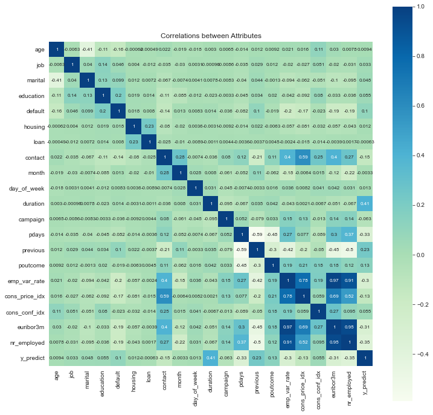

```python
# Before going through machine learning applications, let's see the correlation btw features and target variable by plotting heatmap:
fig = plt.subplots (figsize = (12, 12))
sns.heatmap(data1.corr (), square = True, cbar = True, annot = True, cmap="GnBu", annot_kws = {'size': 8})
plt.title('Correlations between Attributes')
plt.show ()
```

## Implementation of ML Algorithms

To predict whether the customer will subscribe to their Bank Term Deposit (“Yes” or “No”), we are going to apply below algorithms respectively on the training and test dataset. After that, we are going to choose the best model for our data set and create target values for test dataset.

- Logistic regression
- Decision tree
- Random forest
- KNN

### Logistic Regression

```python
from sklearn.linear_model import LogisticRegression
lr = LogisticRegression(multi_class = 'multinomial', solver = 'sag',  max_iter = 10000)
lr.fit(x_train, y_train)
```

```
LogisticRegression(max_iter=10000, multi_class='multinomial', solver='sag')
```

```python
y_pred_lr = lr.predict(x_valid)
```

```python
from sklearn import metrics
from sklearn.metrics import classification_report, confusion_matrix, accuracy_score
confusion_matrix = metrics.confusion_matrix(y_valid, y_pred_lr)
confusion_matrix
```

```
array([[8563,  213],
       [ 678,  431]], dtype=int64)
```

```python
acc_lr = metrics.accuracy_score(y_valid, y_pred_lr)
acc_lr
```

```
0.9098634294385433
```

### Decision Tree

Decision tree is one of the most popular supervised learning algorithm that is mostly used in classification problems.

```python
from sklearn.tree import DecisionTreeClassifier
dt = DecisionTreeClassifier(random_state=101)
dt_model = dt.fit(x_train, y_train)
```

```python
y_pred_dt = dt.predict(x_valid)
```

```python
dt_model
```

```
DecisionTreeClassifier(random_state=101)
```

```python
print(metrics.confusion_matrix(y_valid, y_pred_dt))
```

```
[[8202  574]
 [ 539  570]]
```

```python
# Even though precision and recall are good measures for imbalanced data, we can touch on these concepts here:
print(metrics.classification_report(y_valid, y_pred_dt))
```

```
              precision    recall  f1-score   support

           0       0.94      0.93      0.94      8776
           1       0.50      0.51      0.51      1109

    accuracy                           0.89      9885
   macro avg       0.72      0.72      0.72      9885
weighted avg       0.89      0.89      0.89      9885
```

To interpret the numbers in classification report:  
Precision and recall metrices should be high as possible. They gives us accuracy level out of different classes.  
We use f1-score to compare models that have different precision and recall levels.

```python
acc_dt = metrics.accuracy_score(y_valid, y_pred_dt)
acc_dt
```

```
0.8874051593323217
```

### Random Forest

Random forest is a type of ensemble method of machine learning. It deals with overfitting problem and increase accuracy compared to a simple decision tree model.

```python
from sklearn.ensemble import RandomForestClassifier
rf = RandomForestClassifier(n_estimators = 100, random_state=101, criterion = 'entropy', oob_score = True)
model_rf = rf.fit(x_train, y_train)
```

```python
y_pred_rf = rf.predict(x_valid)
```

```python
print(metrics.confusion_matrix(y_valid, y_pred_rf))
```

```
[[8471  305]
 [ 556  553]]
```

```python
# Create confusion matrix
pd.crosstab(y_valid, y_pred_rf, rownames=['Actual Class'], colnames=['Predicted Class'])
```

| Predicted Class Actual Class | 0 | 1 |
| --- | --- | --- |
| 0 | 8471 | 305 |
| 1 | 556 | 553 |

```python
acc_rf = metrics.accuracy_score(y_valid, y_pred_rf)
acc_rf
```

```
0.9128983308042489
```

We see that accuracy score in random forest model is higher than decision tree accuracy score.

### K-Nearest Neighbors (KNN)

'K' is the number of nearest training points which we classify them using the majority vote.

```python
from sklearn.neighbors import KNeighborsClassifier
model_knn = KNeighborsClassifier(n_neighbors=3)
model_knn.fit(x_train, y_train)
```

```
KNeighborsClassifier(n_neighbors=3)
```

```python
y_pred_knn = model_knn.predict(x_valid)
```

```python
print(metrics.confusion_matrix(y_valid, y_pred_knn))
```

```
[[8334  442]
 [ 599  510]]
```

```python
from sklearn.metrics import classification_report, confusion_matrix, accuracy_score
acc_knn = accuracy_score(y_valid, y_pred_knn)
acc_knn
```

```
0.8946889226100152
```

## Conclusion

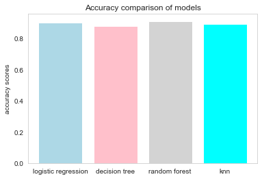

```python
models = ['logistic regression', 'decision tree', 'random forest', 'knn']
acc_scores = [0.90, 0.88, 0.91, 0.89]

plt.bar(models, acc_scores, color=['lightblue', 'pink', 'lightgrey', 'cyan'])
plt.ylabel("accuracy scores")
plt.title("Accuracy comparison of models")
plt.show()
```

After training our dataset with four different model, we conclude that Random Forest is best model for our dataset. (via the highest accuracy score = 0.91)  
Finally, we can run our Random Forest model to predict target values on the test dataset and add labels to dataset.

```python
data2 = pd.read_csv("C:/Users/Manoj/Desktop/Final Project/test.csv")
```

```python
data2.head()
```

|  | age | job | marital | education | default | housing | loan | contact | month | day_of_week | duration | campaign | pdays | previous | poutcome | emp.var.rate | cons.price.idx | cons.conf.idx | euribor3m | nr.employed |
| --- | --- | --- | --- | --- | --- | --- | --- | --- | --- | --- | --- | --- | --- | --- | --- | --- | --- | --- | --- | --- |
| 0 | 40 | admin. | married | basic.6y | no | no | no | telephone | may | mon | 151 | 1 | 999 | 0 | nonexistent | 1.1 | 93.994 | -36.4 | 4.857 | 5191.0 |
| 1 | 59 | admin. | married | professional.course | no | no | no | telephone | may | mon | 139 | 1 | 999 | 0 | nonexistent | 1.1 | 93.994 | -36.4 | 4.857 | 5191.0 |
| 2 | 54 | retired | married | basic.9y | unknown | yes | yes | telephone | may | mon | 174 | 1 | 999 | 0 | nonexistent | 1.1 | 93.994 | -36.4 | 4.857 | 5191.0 |
| 3 | 35 | blue-collar | married | basic.6y | no | yes | no | telephone | may | mon | 312 | 1 | 999 | 0 | nonexistent | 1.1 | 93.994 | -36.4 | 4.857 | 5191.0 |
| 4 | 59 | technician | married | unknown | no | yes | no | telephone | may | mon | 93 | 1 | 999 | 0 | nonexistent | 1.1 | 93.994 | -36.4 | 4.857 | 5191.0 |

```python
data2 = data2.rename(columns={'emp.var.rate': 'emp_var_rate', 'cons.price.idx': 'cons_price_idx', 'cons.conf.idx': 'cons_conf_idx', 'nr.employed': 'nr_employed'})
data2
```

|  | age | job | marital | education | default | housing | loan | contact | month | day_of_week | duration | campaign | pdays | previous | poutcome | emp_var_rate | cons_price_idx | cons_conf_idx | euribor3m | nr_employed |
| --- | --- | --- | --- | --- | --- | --- | --- | --- | --- | --- | --- | --- | --- | --- | --- | --- | --- | --- | --- | --- |
| 0 | 40 | admin. | married | basic.6y | no | no | no | telephone | may | mon | 151 | 1 | 999 | 0 | nonexistent | 1.1 | 93.994 | -36.4 | 4.857 | 5191.0 |
| 1 | 59 | admin. | married | professional.course | no | no | no | telephone | may | mon | 139 | 1 | 999 | 0 | nonexistent | 1.1 | 93.994 | -36.4 | 4.857 | 5191.0 |
| 2 | 54 | retired | married | basic.9y | unknown | yes | yes | telephone | may | mon | 174 | 1 | 999 | 0 | nonexistent | 1.1 | 93.994 | -36.4 | 4.857 | 5191.0 |
| 3 | 35 | blue-collar | married | basic.6y | no | yes | no | telephone | may | mon | 312 | 1 | 999 | 0 | nonexistent | 1.1 | 93.994 | -36.4 | 4.857 | 5191.0 |
| 4 | 59 | technician | married | unknown | no | yes | no | telephone | may | mon | 93 | 1 | 999 | 0 | nonexistent | 1.1 | 93.994 | -36.4 | 4.857 | 5191.0 |
| ... | ... | ... | ... | ... | ... | ... | ... | ... | ... | ... | ... | ... | ... | ... | ... | ... | ... | ... | ... | ... |
| 8233 | 62 | services | married | high.school | no | yes | no | cellular | nov | wed | 154 | 5 | 999 | 0 | nonexistent | -1.1 | 94.767 | -50.8 | 1.030 | 4963.6 |
| 8234 | 40 | management | divorced | university.degree | no | yes | no | cellular | nov | wed | 293 | 2 | 999 | 4 | failure | -1.1 | 94.767 | -50.8 | 1.030 | 4963.6 |
| 8235 | 33 | student | married | professional.course | no | yes | no | telephone | nov | thu | 112 | 1 | 999 | 0 | nonexistent | -1.1 | 94.767 | -50.8 | 1.031 | 4963.6 |
| 8236 | 62 | retired | married | university.degree | no | no | no | cellular | nov | thu | 483 | 2 | 6 | 3 | success | -1.1 | 94.767 | -50.8 | 1.031 | 4963.6 |
| 8237 | 73 | retired | married | professional.course | no | yes | no | cellular | nov | fri | 334 | 1 | 999 | 0 | nonexistent | -1.1 | 94.767 | -50.8 | 1.028 | 4963.6 |

8238 rows × 20 columns

```python
data2[['job', 'marital', 'education', 'default', 'housing', 'loan','contact', 'month', 'day_of_week', 'poutcome']] = data1[['job', 'marital', 'education', 'default', 'housing', 'loan','contact', 'month', 'day_of_week', 'poutcome']].astype(str)
```

```python
from sklearn.preprocessing import LabelEncoder
LE=LabelEncoder()
cat_var=['job', 'marital', 'education', 'default', 'housing', 'loan', 'contact', 'month', 'day_of_week','poutcome']
for i in cat_var:
    data1[i]=LE.fit_transform(data1[i])

data1.head()
```

|  | age | job | marital | education | default | housing | loan | contact | month | day_of_week | ... | campaign | pdays | previous | poutcome | emp_var_rate | cons_price_idx | cons_conf_idx | euribor3m | nr_employed | y_predict |
| --- | --- | --- | --- | --- | --- | --- | --- | --- | --- | --- | --- | --- | --- | --- | --- | --- | --- | --- | --- | --- | --- |
| 0 | 3 | 0 | 1 | 7 | 1 | 1 | 2 | 1 | 3 | 0 | ... | 2 | 999 | 0 | 1 | 1.4 | 93.918 | -42.7 | 4.963 | 5228.1 | 0 |
| 1 | 2 | 8 | 1 | 3 | 1 | 2 | 2 | 1 | 6 | 3 | ... | 1 | 999 | 0 | 1 | 1.1 | 93.994 | -36.4 | 4.857 | 5191.0 | 0 |
| 2 | 2 | 3 | 1 | 3 | 0 | 2 | 1 | 1 | 4 | 1 | ... | 7 | 999 | 0 | 1 | 1.4 | 94.465 | -41.8 | 4.961 | 5228.1 | 0 |
| 3 | 3 | 8 | 1 | 3 | 0 | 2 | 1 | 1 | 6 | 4 | ... | 3 | 999 | 0 | 1 | 1.1 | 93.994 | -36.4 | 4.859 | 5191.0 | 0 |
| 4 | 3 | 1 | 1 | 2 | 1 | 1 | 1 | 1 | 6 | 0 | ... | 3 | 999 | 0 | 1 | 1.1 | 93.994 | -36.4 | 4.864 | 5191.0 | 0 |

5 rows × 21 columns

```python
def age(dataframe):
    dataframe.loc[dataframe['age'] <= 32, 'age'] = 1
    dataframe.loc[(dataframe['age'] > 32) & (dataframe['age'] <= 47), 'age'] = 2
    dataframe.loc[(dataframe['age'] > 47) & (dataframe['age'] <= 70), 'age'] = 3
    dataframe.loc[(dataframe['age'] > 70) & (dataframe['age'] <= 98), 'age'] = 4

    return dataframe

age(data2);
```

```python
data2
```

|  | age | job | marital | education | default | housing | loan | contact | month | day_of_week | duration | campaign | pdays | previous | poutcome | emp_var_rate | cons_price_idx | cons_conf_idx | euribor3m | nr_employed |
| --- | --- | --- | --- | --- | --- | --- | --- | --- | --- | --- | --- | --- | --- | --- | --- | --- | --- | --- | --- | --- |
| 0 | 2 | 0 | 1 | 7 | 1 | 1 | 2 | 1 | 3 | 0 | 151 | 1 | 999 | 0 | 1 | 1.1 | 93.994 | -36.4 | 4.857 | 5191.0 |
| 1 | 3 | 8 | 1 | 3 | 1 | 2 | 2 | 1 | 6 | 3 | 139 | 1 | 999 | 0 | 1 | 1.1 | 93.994 | -36.4 | 4.857 | 5191.0 |
| 2 | 3 | 3 | 1 | 3 | 0 | 2 | 1 | 1 | 4 | 1 | 174 | 1 | 999 | 0 | 1 | 1.1 | 93.994 | -36.4 | 4.857 | 5191.0 |
| 3 | 2 | 8 | 1 | 3 | 0 | 2 | 1 | 1 | 6 | 4 | 312 | 1 | 999 | 0 | 1 | 1.1 | 93.994 | -36.4 | 4.857 | 5191.0 |
| 4 | 3 | 1 | 1 | 2 | 1 | 1 | 1 | 1 | 6 | 0 | 93 | 1 | 999 | 0 | 1 | 1.1 | 93.994 | -36.4 | 4.857 | 5191.0 |
| ... | ... | ... | ... | ... | ... | ... | ... | ... | ... | ... | ... | ... | ... | ... | ... | ... | ... | ... | ... | ... |
| 8233 | 3 | 8 | 3 | 3 | 1 | 1 | 1 | 1 | 4 | 1 | 154 | 5 | 999 | 0 | 1 | -1.1 | 94.767 | -50.8 | 1.030 | 4963.6 |
| 8234 | 2 | 8 | 1 | 3 | 0 | 2 | 1 | 1 | 6 | 1 | 293 | 2 | 999 | 4 | 1 | -1.1 | 94.767 | -50.8 | 1.030 | 4963.6 |
| 8235 | 2 | 10 | 1 | 3 | 1 | 2 | 1 | 0 | 3 | 3 | 112 | 1 | 999 | 0 | 1 | -1.1 | 94.767 | -50.8 | 1.031 | 4963.6 |
| 8236 | 3 | 4 | 1 | 7 | 1 | 2 | 2 | 0 | 7 | 1 | 483 | 2 | 6 | 3 | 1 | -1.1 | 94.767 | -50.8 | 1.031 | 4963.6 |
| 8237 | 4 | 0 | 1 | 7 | 0 | 2 | 2 | 0 | 1 | 1 | 334 | 1 | 999 | 0 | 1 | -1.1 | 94.767 | -50.8 | 1.028 | 4963.6 |

8238 rows × 20 columns

```python
predicted_CX_subscription = model_rf.predict(data2)
```

```python
# We are able to forecast test dataset labels:
predicted_CX_subscription
```

```
array([0, 0, 0, ..., 0, 1, 1])
```

```python
data2['y_predict'] = predicted_CX_subscription
data2.head()
```

|  | age | job | marital | education | default | housing | loan | contact | month | day_of_week | ... | campaign | pdays | previous | poutcome | emp_var_rate | cons_price_idx | cons_conf_idx | euribor3m | nr_employed | y_predict |
| --- | --- | --- | --- | --- | --- | --- | --- | --- | --- | --- | --- | --- | --- | --- | --- | --- | --- | --- | --- | --- | --- |
| 0 | 2 | 0 | 1 | 7 | 1 | 1 | 2 | 1 | 3 | 0 | ... | 1 | 999 | 0 | 1 | 1.1 | 93.994 | -36.4 | 4.857 | 5191.0 | 0 |
| 1 | 3 | 8 | 1 | 3 | 1 | 2 | 2 | 1 | 6 | 3 | ... | 1 | 999 | 0 | 1 | 1.1 | 93.994 | -36.4 | 4.857 | 5191.0 | 0 |
| 2 | 3 | 3 | 1 | 3 | 0 | 2 | 1 | 1 | 4 | 1 | ... | 1 | 999 | 0 | 1 | 1.1 | 93.994 | -36.4 | 4.857 | 5191.0 | 0 |
| 3 | 2 | 8 | 1 | 3 | 0 | 2 | 1 | 1 | 6 | 4 | ... | 1 | 999 | 0 | 1 | 1.1 | 93.994 | -36.4 | 4.857 | 5191.0 | 0 |
| 4 | 3 | 1 | 1 | 2 | 1 | 1 | 1 | 1 | 6 | 0 | ... | 1 | 999 | 0 | 1 | 1.1 | 93.994 | -36.4 | 4.857 | 5191.0 | 0 |

5 rows × 21 columns

```python
data2
```

|  | age | job | marital | education | default | housing | loan | contact | month | day_of_week | ... | campaign | pdays | previous | poutcome | emp_var_rate | cons_price_idx | cons_conf_idx | euribor3m | nr_employed | y_predict |
| --- | --- | --- | --- | --- | --- | --- | --- | --- | --- | --- | --- | --- | --- | --- | --- | --- | --- | --- | --- | --- | --- |
| 0 | 2 | 0 | 1 | 7 | 1 | 1 | 2 | 1 | 3 | 0 | ... | 1 | 999 | 0 | 1 | 1.1 | 93.994 | -36.4 | 4.857 | 5191.0 | 0 |
| 1 | 3 | 8 | 1 | 3 | 1 | 2 | 2 | 1 | 6 | 3 | ... | 1 | 999 | 0 | 1 | 1.1 | 93.994 | -36.4 | 4.857 | 5191.0 | 0 |
| 2 | 3 | 3 | 1 | 3 | 0 | 2 | 1 | 1 | 4 | 1 | ... | 1 | 999 | 0 | 1 | 1.1 | 93.994 | -36.4 | 4.857 | 5191.0 | 0 |
| 3 | 2 | 8 | 1 | 3 | 0 | 2 | 1 | 1 | 6 | 4 | ... | 1 | 999 | 0 | 1 | 1.1 | 93.994 | -36.4 | 4.857 | 5191.0 | 0 |
| 4 | 3 | 1 | 1 | 2 | 1 | 1 | 1 | 1 | 6 | 0 | ... | 1 | 999 | 0 | 1 | 1.1 | 93.994 | -36.4 | 4.857 | 5191.0 | 0 |
| ... | ... | ... | ... | ... | ... | ... | ... | ... | ... | ... | ... | ... | ... | ... | ... | ... | ... | ... | ... | ... | ... |
| 8233 | 3 | 8 | 3 | 3 | 1 | 1 | 1 | 1 | 4 | 1 | ... | 5 | 999 | 0 | 1 | -1.1 | 94.767 | -50.8 | 1.030 | 4963.6 | 0 |
| 8234 | 2 | 8 | 1 | 3 | 0 | 2 | 1 | 1 | 6 | 1 | ... | 2 | 999 | 4 | 1 | -1.1 | 94.767 | -50.8 | 1.030 | 4963.6 | 1 |
| 8235 | 2 | 10 | 1 | 3 | 1 | 2 | 1 | 0 | 3 | 3 | ... | 1 | 999 | 0 | 1 | -1.1 | 94.767 | -50.8 | 1.031 | 4963.6 | 0 |
| 8236 | 3 | 4 | 1 | 7 | 1 | 2 | 2 | 0 | 7 | 1 | ... | 2 | 6 | 3 | 1 | -1.1 | 94.767 | -50.8 | 1.031 | 4963.6 | 1 |
| 8237 | 4 | 0 | 1 | 7 | 0 | 2 | 2 | 0 | 1 | 1 | ... | 1 | 999 | 0 | 1 | -1.1 | 94.767 | -50.8 | 1.028 | 4963.6 | 1 |

8238 rows × 21 columns